# Forecasting Forest Fires: The Role of Fire Weather Indices

Joudy Allam, Haya Mazyad, Nour Saad

December 08, 2024

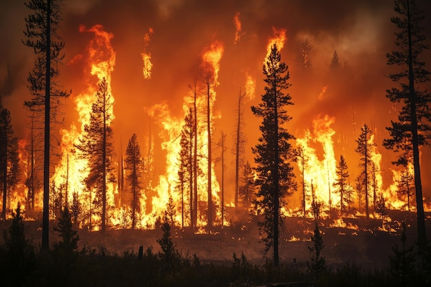

# Introduction

Forest fires are a significant environmental disaster that cause immense economic and ecological damage and pose a threat to human lives. Accurate prediction of such critical events is essential to mitigate these threats effectively. This project aims to develop machine learning models to predict forest fires using a dataset of fire weather indices collected from two regions in Canada, Cordillera and Hudson Bay.

## Dataset Description

The dataset titled `forest_fires_dataset.csv` includes 244 observations with the following features:

- **Date**: Observations from June to September 2012.
- **Temp**: Maximum temperature at noon in Celsius.
- **RH**: Relative Humidity in percentage.
- **Ws**: Wind speed in km/h.
- **Rain**: Total precipitation in mm.
- **FWI Components**: The Canadian Forest Fire Weather Index System includes six components calculated based on consecutive daily observations of temp, RH, Ws, and Rain, and that provide numeric ratings of relative potential for wildland fire:
  - **Fuel Moisture Codes**: These are numeric ratings that represent the moisture content of the forest floor and other dead organic matter across three distinct layers. As the moisture content decreases, the numeric value of these codes increases, signaling drier conditions more susceptible to ignition and sustained burning.
    1. **Fine Fuel Moisture Code (FFMC)**: Rates the moisture content of surface litter and cured fine fuels, affecting ignition ease and flammability.
    2. **Duff Moisture Code (DMC)**: Represents the moisture content of loosely compacted organic layers, affecting fuel consumption in moderate duff layers and medium-sized woody materials.
    3. **Drought Code (DC)**: Indicates the moisture content in deep, compact organic layers, serving as a seasonal drought effect indicator on forest fuels and the amount of smoldering in deep duff layers and large logs.
  - **Fire Behavior Indices**
    1. **Initial Spread Index (ISI)**: Predicts the rate of fire spread based on wind speed and *FFMC*.
    2. **Buildup Index (BUI)**: Quantifies the total fuel available for combustion, based on DMC and DC values.
    3. **Fire Weather Index (FWI)**: A composite index of fire intensity derived from ISI and BUI, used widely to gauge fire danger across forested areas of Canada.
- **Classes**: Fire occurrence categorized as “fire” or “not fire”.

## Objective

The goal is to build and compare various machine learning models based on the provided fire weather indices to predict the likelihood of forest fires.

# Data Loading and Preprocessing

We have loaded the following R packages, each chosen for their specific capabilities in data processing, analysis, and visualization:

- **dplyr**: Utilized for its powerful data manipulation tools, enabling data filtering, selection, and transformation.
- **tidyr**: Essential for tidying data, transforming it into a format that is easy to analyze and manipulate.
- **readr**: Efficiently reads and writes tabular data, streamlining the process of data input and output.
- **caret**: A comprehensive package for building and assessing machine learning models, offering a wide range of tools for model training and evaluation.
- **ggplot2**: Based on the Grammar of Graphics, this package allows for the creation of complex, layered statistical graphics.
- **GGally**: Extends ggplot2, adding additional functionality for plotting common statistical figures.
- **randomForest**: Implements the random forest algorithm for classification and regression tasks, providing robust and interpretable models.
- **caTools**: Includes tools for splitting data sets, generating ROC curves, and other miscellaneous methods useful in data analysis.
- **stats**: Provides a wide array of statistical functions including probability distributions, regression models, and cluster analysis.
- **pROC**: Specialized in ROC analysis, offering tools to visualize and evaluate classifiers’ performance.
- **MASS**: Offers a variety of statistical functions that support the content of the book “Modern Applied Statistics with S,” which includes logistic regression, linear discriminant analysis, and more.
- **class**: Contains functions for k-nearest neighbors (KNN) classification, a simple yet effective machine learning technique.
- **rpart**: Facilitates recursive partitioning for the creation of decision trees, used in classification and regression models.
- **rpart.plot**: Enhances decision tree visualizations created with rpart, making them more interpretable.
- **gbm**: Implements gradient boosting models that are effective for dealing with various types of predictive modeling problems.
- **e1071**: A versatile package that includes support vector machines, Fourier transforms, and other statistical tools.
- **DescTools**: Offers tools for descriptive statistics and data transformations, including Winsorization and various statistical tests.
- **bslib**: Enables the customization of themes for Shiny and R Markdown applications, improving the aesthetic appeal and user experience of data visualizations and applications.
- **knitr**: Allows for dynamic report generation with R, making it easier to integrate R code into LaTeX, HTML, Markdown, or other document formats.
- **kableExtra**: Enhances tables generated with knitr::kable() by providing additional styling options and functionalities.

Each package is integral to performing comprehensive data analysis, from preprocessing to model evaluation, ensuring robust and efficient processing across various stages of our project.

```r
library(dplyr)
library(tidyr)
library(readr)
library(caret)
library(ggplot2)
library(GGally)
library(randomForest)
library(caTools)
library(stats)
library(pROC)
library(MASS)
library(class)
library(rpart)
library(rpart.plot)
library(gbm)
library(e1071)
library(DescTools)
library(bslib)
library(knitr)
library(kableExtra)
```

## Load Data

We begin by loading the dataset `forest_fires_dataset.csv` from a specified path. It’s important to ensure the path is correctly set to the location of the dataset on your local machine or server. During the loading process, we handle initial data cleanliness by replacing all empty strings with `NA`. This is done to standardize missing value representation across the dataset, making subsequent data cleaning steps more straightforward.

```r
# Modify the path as needed to point to the actual file location
fire_data <- read.csv("C:/Users/User/Desktop/University/BIF524 - Data Mining/Project/forest_fires_dataset.csv", header = FALSE) %>%
  # Replace empty strings with NA across all columns
  mutate(across(everything(), ~na_if(.x, "")))
```

## Preliminary data inspection

After loading the data, it’s crucial to inspect its structure to understand its format and the nature of the data we’re dealing with.

```r
str(fire_data)        # Display the structure of the dataframe
```

```
## 'data.frame':    249 obs. of  14 variables:
##  $ V1 : chr  "Cordillera" "day" "1" "2" ...
##  $ V2 : chr  NA "month" "6" "6" ...
##  $ V3 : chr  NA "year" "2012" "2012" ...
##  $ V4 : chr  NA "Temperature" "29" "29" ...
##  $ V5 : chr  NA " RH" "57" "61" ...
##  $ V6 : chr  NA " Ws" "18" "13" ...
##  $ V7 : chr  NA "Rain " "0" "1.3" ...
##  $ V8 : chr  NA "FFMC" "65.7" "64.4" ...
##  $ V9 : chr  NA "DMC" "3.4" "4.1" ...
##  $ V10: chr  NA "DC" "7.6" "7.6" ...
##  $ V11: chr  NA "ISI" "1.3" "1" ...
##  $ V12: chr  NA "BUI" "3.4" "3.9" ...
##  $ V13: chr  NA "FWI" "0.5" "0.4" ...
##  $ V14: chr  NA "Classes  " "not fire   " "not fire   " ...
```

```r
summary(fire_data)    # Summarize the data to get a statistical overview
```

```
##       V1                 V2                 V3                 V4
##  Length:249         Length:249         Length:249         Length:249
##  Class :character   Class :character   Class :character   Class :character
##  Mode  :character   Mode  :character   Mode  :character   Mode  :character
##       V5                 V6                 V7                 V8
##  Length:249         Length:249         Length:249         Length:249
##  Class :character   Class :character   Class :character   Class :character
##  Mode  :character   Mode  :character   Mode  :character   Mode  :character
##       V9                V10                V11                V12
##  Length:249         Length:249         Length:249         Length:249
##  Class :character   Class :character   Class :character   Class :character
##  Mode  :character   Mode  :character   Mode  :character   Mode  :character
##      V13                V14
##  Length:249         Length:249
##  Class :character   Class :character
##  Mode  :character   Mode  :character
```

Upon initial inspection, we observe the following characteristics of our data:

- **Header Presence**: The dataset is loaded without predefined headers (`header = FALSE`), resulting in generic column names (V1 to V14). This was expected and intentional, allowing for flexible data manipulation and customized header assignment based on dataset specifics.
- **Data Sectioning**: The dataset is structured into sections for two distinct locations: “Cordillera” and “Hudson Bay”. Each section is preceded by specific headers and separated by empty lines, indicating a structured pattern in our dataset where different location data are interspersed with metadata.
- **Column Names and Data Rows**: Each data section starts with a row indicating the location name followed by another row containing column names such as “*day*”, “*month*”, “*year*”, “*Temperature*”, “*RH*”, “*Ws*”, “*Rain*”, “*FFMC*”, “*DMC*”, “*DC*”, “*ISI*”, “*BUI*”, “*FWI*”, and “*Classes*”. These headers are crucial for understanding the content of each column and will be programmatically set in the dataframe.
- **Character Data Type**: All columns were initially read as character strings (`chr`). This necessitates a planned conversion to appropriate data types (numeric or factor), which will enable accurate statistical analysis and machine learning modeling.
- **Data Cleaning Needs**: Initial observations show that data points are not consistently stripped of spaces (e.g., “Classes”, “not fire”, and ” Ws”). Moreover, the presence of redundant rows used as headers within the data sections and potential NA values will require careful cleaning to ensure the dataset’s integrity and usability.

#### Step 1: Handling Location Metadata and Headers

In this step, we address the initial data organization by managing location information and setting up proper headers. Our objective is not to lose the location information but rather enhance its clarity by integrating it directly into the dataset. This involves creating a new ‘*Location*’ column and ensuring that each data point is associated with its respective location.

**Process Explanation**:

- **Data Separation**: The dataset includes data for two distinct locations (“Cordillera” and “Hudson Bay”), separated by an empty line. We first split the dataset at this line to handle each location separately.
- **Header and Location Management**: For each split dataset:
- **Set Column Names**: The second row of each section contains the appropriate column names, which we assign as headers for the dataset.
- **Add Location Column**: The first row of each section specifies the location. We extract this information and create a new ‘Location’ column to ensure each row is labeled with its corresponding location.
- **Remove Redundant Rows**: The first two rows of each section (location name and column headers) are removed after their information is captured and set properly.
- **Combining Data**: The cleaned data parts (`df_part1` and `df_part2`), each now containing appropriate headers and a new ‘Location’ column, are combined into one unified dataset `final_data`. This is done using the `bind_rows()` function, which stacks the two data frames vertically, preserving the order and the integrity of the data.

```r
# Find the index of the first NA in the first column, indicating the break between data sections
break_indices <- which(is.na(fire_data$V1))


# Split the data into two parts based on the location of the break
df_part1 <- fire_data[1:(break_indices[1] - 1), ]
df_part2 <- fire_data[(break_indices[1] + 1):nrow(fire_data), ]


# For each data section (each section represents the data of one location):
  # Set column names from the second row (header)
  # Add a 'Location' column: assign location from the first row ('Cordillera' or 'Hudson Bay')
  # Remove the first two rows
names(df_part1) <- make.names(trimws(unlist(df_part1[2, ])))
df_part1$Location <- df_part1[1,1]
df_part1 <- df_part1[-c(1,2),]

names(df_part2) <- make.names(trimws(unlist(df_part2[2, ])))
df_part2$Location <- df_part2[1,1]
df_part2 <- df_part2[-c(1,2),]


#Combine the two parts back into a single dataframe
final_data <- bind_rows(df_part1, df_part2)
```

#### Step 2: Data Type Conversion

Initially, all data columns were read as characters due to the CSV import settings. We converted these columns to their appropriate data types to ensure accurate computations and analyses later in our project.

We converted key variables like *Temperature* and *Rain* to numeric types to enable essential operations such as averaging and summing, crucial for our data analysis and modeling tasks.

```r
# Convert all columns from character to their appropriate data types, correcting the initial read format

## Convert specified columns to numeric types as they were initially read as characters
numeric_columns <- c("Temperature", "RH", "Ws", "Rain", "FFMC", "DMC", "DC", "ISI", "BUI", "FWI")
final_data[numeric_columns] <- lapply(final_data[numeric_columns], as.numeric)
```

We refined categorical data to enhance the clarity and utility of the dataset for analysis and modeling.

This involved several key adjustments:

- **Trimming Whitespace**: We used the `trimws` function to ensure all entries in the ‘*Classes*’ column were consistent, removing any leading or trailing spaces. This step is crucial to prevent errors and misclassifications during data processing.
- **Factorization of ‘*Classes*’**: We converted the ‘*Classes*’ column into a factor with defined levels (‘not fire’, ‘fire’). This not only clarifies the categorical nature of this variable but also establishes ‘not fire’ as the baseline category, which is important for the interpretability of statistical models.
- **Creation of ‘*ClassesN*’**: To accommodate statistical methods and machine learning models that require numeric inputs, we created a numeric version of the ‘*Classes*’ column (‘*ClassesN*’). This provides a straightforward numeric encoding (0 for ‘not fire’, 1 for ‘fire’), facilitating model compatibility and simplification.
- **Location Factorization**: We factorized the ‘*Location*’ column with ‘Cordillera’ as the reference category to ensure that our analyses could accurately reflect differences between the two geographic areas, ‘Cordillera’ and ‘Hudson Bay’. This standardization is vital for any models that assess the impact of location on fire occurrences, ensuring consistent and comparable results across different regions.

```r
# Clean up and factorize the 'Classes' column
# Trim whitespace and set 'not fire' as the first level for a consistent reference in models
final_data$Classes <- factor(trimws(final_data$Classes), levels = c("not fire", "fire"))
# Create a numeric version of the 'Classes' column for models that require numeric input
final_data$ClassesN <- ifelse(final_data$Classes == "fire", 1, 0)

# Factorize the 'Location' column with 'Cordillera' as the reference category
final_data$Location <- factor(final_data$Location, levels = c("Cordillera", "Hudson Bay"))
```

#### Step 3: Handling missing values

Handling missing values is crucial because they can distort statistical analyses and lead to misleading conclusions.

First, we identify if there are any missing values in our dataset and determine their extent. This helps us decide the appropriate action to take based on how significantly the missing data might affect our dataset.

```r
# Count the number of rows with at least one missing value
num_rows_with_missing <- sum(apply(final_data, 1, function(x) any(is.na(x))))

# Calculate the total number of rows in the data frame
total_rows <- nrow(final_data)

# Calculate the percentage of rows with missing values
percentage_with_missing <- (num_rows_with_missing / total_rows) * 100

# Print the number of rows with missing values and the percentage
cat("Number of rows with missing values:", num_rows_with_missing, "\n")
```

```
## Number of rows with missing values: 1
```

```r
cat("Percentage of rows with missing values:", sprintf("%.2f%%", percentage_with_missing), "\n")
```

```
## Percentage of rows with missing values: 0.41%
```

Given that there is only one missing entry out of 244 (0.41%), we have decided to omit this row. The impact of removing such a small fraction is minimal, and it simplifies our dataset preparation. Addressing this single case with more complex imputation methods would not be cost-effective and could potentially introduce bias, making it more pragmatic to exclude it from our analysis.

```r
# Remove rows that contain any missing values to prepare clean dataset for analysis
final_data <- na.omit(final_data)
```

Now, we will reexamine the structure and summary statistics of the cleaned dataset to ensure its readiness for further analysis.

```r
# Display the structure and summary of the cleaned data
str(final_data)
```

```
## 'data.frame':    243 obs. of  16 variables:
##  $ day        : chr  "1" "2" "3" "4" ...
##  $ month      : chr  "6" "6" "6" "6" ...
##  $ year       : chr  "2012" "2012" "2012" "2012" ...
##  $ Temperature: num  29 29 26 25 27 31 33 30 25 28 ...
##  $ RH         : num  57 61 82 89 77 67 54 73 88 79 ...
##  $ Ws         : num  18 13 22 13 16 14 13 15 13 12 ...
##  $ Rain       : num  0 1.3 13.1 2.5 0 0 0 0 0.2 0 ...
##  $ FFMC       : num  65.7 64.4 47.1 28.6 64.8 82.6 88.2 86.6 52.9 73.2 ...
##  $ DMC        : num  3.4 4.1 2.5 1.3 3 5.8 9.9 12.1 7.9 9.5 ...
##  $ DC         : num  7.6 7.6 7.1 6.9 14.2 22.2 30.5 38.3 38.8 46.3 ...
##  $ ISI        : num  1.3 1 0.3 0 1.2 3.1 6.4 5.6 0.4 1.3 ...
##  $ BUI        : num  3.4 3.9 2.7 1.7 3.9 7 10.9 13.5 10.5 12.6 ...
##  $ FWI        : num  0.5 0.4 0.1 0 0.5 2.5 7.2 7.1 0.3 0.9 ...
##  $ Classes    : Factor w/ 2 levels "not fire","fire": 1 1 1 1 1 2 2 2 1 1 ...
##  $ Location   : Factor w/ 2 levels "Cordillera","Hudson Bay": 1 1 1 1 1 1 1 1 1 1 ...
##  $ ClassesN   : num  0 0 0 0 0 1 1 1 0 0 ...
##  - attr(*, "na.action")= 'omit' Named int 166
##   ..- attr(*, "names")= chr "166"
```

```r
summary(final_data)
```

```
##      day               month               year            Temperature
##  Length:243         Length:243         Length:243         Min.   :22.00
##  Class :character   Class :character   Class :character   1st Qu.:30.00
##  Mode  :character   Mode  :character   Mode  :character   Median :32.00
##                                                           Mean   :32.15
##                                                           3rd Qu.:35.00
##                                                           Max.   :42.00
##        RH              Ws             Rain             FFMC
##  Min.   :21.00   Min.   : 6.00   Min.   : 0.000   Min.   :28.60
##  1st Qu.:52.50   1st Qu.:14.00   1st Qu.: 0.000   1st Qu.:71.85
##  Median :63.00   Median :15.00   Median : 0.000   Median :83.30
##  Mean   :62.04   Mean   :15.49   Mean   : 0.763   Mean   :77.84
##  3rd Qu.:73.50   3rd Qu.:17.00   3rd Qu.: 0.500   3rd Qu.:88.30
##  Max.   :90.00   Max.   :29.00   Max.   :16.800   Max.   :96.00
##       DMC              DC              ISI              BUI
##  Min.   : 0.70   Min.   :  6.90   Min.   : 0.000   Min.   : 1.10
##  1st Qu.: 5.80   1st Qu.: 12.35   1st Qu.: 1.400   1st Qu.: 6.00
##  Median :11.30   Median : 33.10   Median : 3.500   Median :12.40
##  Mean   :14.68   Mean   : 49.43   Mean   : 4.742   Mean   :16.69
##  3rd Qu.:20.80   3rd Qu.: 69.10   3rd Qu.: 7.250   3rd Qu.:22.65
##  Max.   :65.90   Max.   :220.40   Max.   :19.000   Max.   :68.00
##       FWI             Classes          Location      ClassesN
##  Min.   : 0.000   not fire:106   Cordillera:122   Min.   :0.0000
##  1st Qu.: 0.700   fire    :137   Hudson Bay:121   1st Qu.:0.0000
##  Median : 4.200                                   Median :1.0000
##  Mean   : 7.035                                   Mean   :0.5638
##  3rd Qu.:11.450                                   3rd Qu.:1.0000
##  Max.   :31.100                                   Max.   :1.0000
```

#### Step 4: Additional Adjustments

As we transition to exploratory data analysis, we’ve implemented several preprocessing adjustments to refine our dataset: - **Removal of the ‘*Year*’ Column**: The ‘*year*’ column was removed from `final_data` as it contains the same value (2012) across all entries, offering no variability or predictive value for our analyses. Though removed, this column is still accessible in the original fire_data for reference if needed in the future. - **Month Categorization**: The ‘*month*’ column was transformed into a categorical variable. This acknowledges each month’s distinct impact as a separate category. - **Day Categorization**: We recognized that using raw day numbers (1-31) might not effectively capture trends in fire occurrences. Thus, we categorized days into ‘Early’ (1-10), ‘Mid’ (11-20), and ‘Late’ (21-31) to better delineate patterns across the month. This structured approach replaces the original ‘`day`’ with ‘`day_group`’, which offers a more analytically useful segmentation.

While the ‘*year*’ and original ‘*day*’ columns have been removed from `final_data` for a streamlined analysis, they remain available in `fire_data`. This ensures that we retain the ability to reference the complete dataset as needed, preserving the integrity and full scope of the original data for any future requirements or checks.

```r
colnames(final_data)
```

```
##  [1] "day"         "month"       "year"        "Temperature" "RH"
##  [6] "Ws"          "Rain"        "FFMC"        "DMC"         "DC"
## [11] "ISI"         "BUI"         "FWI"         "Classes"     "Location"
## [16] "ClassesN"
```

```r
# Remove 'year' as it does not vary (year = 2012 across all the data)
final_data <- dplyr::select(final_data, -year)

# Convert 'month' to a factor since it might contain seasonal effects
final_data$month <- factor(final_data$month)

# Group 'day' into categories
final_data$day_group <- cut(as.numeric(final_data$day),
                      breaks = c(0, 10, 20, 31),
                      labels = c("Early", "Mid", "Late"))
final_data$day_group <- factor(final_data$day_group)

# Now you can drop the original 'day' if the new grouping is preferred
final_data <- dplyr::select(final_data, -day)

# Display the structure and summary of the cleaned data
str(final_data)
```

```
## 'data.frame':    243 obs. of  15 variables:
##  $ month      : Factor w/ 4 levels "6","7","8","9": 1 1 1 1 1 1 1 1 1 1 ...
##  $ Temperature: num  29 29 26 25 27 31 33 30 25 28 ...
##  $ RH         : num  57 61 82 89 77 67 54 73 88 79 ...
##  $ Ws         : num  18 13 22 13 16 14 13 15 13 12 ...
##  $ Rain       : num  0 1.3 13.1 2.5 0 0 0 0 0.2 0 ...
##  $ FFMC       : num  65.7 64.4 47.1 28.6 64.8 82.6 88.2 86.6 52.9 73.2 ...
##  $ DMC        : num  3.4 4.1 2.5 1.3 3 5.8 9.9 12.1 7.9 9.5 ...
##  $ DC         : num  7.6 7.6 7.1 6.9 14.2 22.2 30.5 38.3 38.8 46.3 ...
##  $ ISI        : num  1.3 1 0.3 0 1.2 3.1 6.4 5.6 0.4 1.3 ...
##  $ BUI        : num  3.4 3.9 2.7 1.7 3.9 7 10.9 13.5 10.5 12.6 ...
##  $ FWI        : num  0.5 0.4 0.1 0 0.5 2.5 7.2 7.1 0.3 0.9 ...
##  $ Classes    : Factor w/ 2 levels "not fire","fire": 1 1 1 1 1 2 2 2 1 1 ...
##  $ Location   : Factor w/ 2 levels "Cordillera","Hudson Bay": 1 1 1 1 1 1 1 1 1 1 ...
##  $ ClassesN   : num  0 0 0 0 0 1 1 1 0 0 ...
##  $ day_group  : Factor w/ 3 levels "Early","Mid",..: 1 1 1 1 1 1 1 1 1 1 ...
##  - attr(*, "na.action")= 'omit' Named int 166
##   ..- attr(*, "names")= chr "166"
```

```r
summary(final_data)
```

```
##  month   Temperature          RH              Ws             Rain
##  6:60   Min.   :22.00   Min.   :21.00   Min.   : 6.00   Min.   : 0.000
##  7:61   1st Qu.:30.00   1st Qu.:52.50   1st Qu.:14.00   1st Qu.: 0.000
##  8:62   Median :32.00   Median :63.00   Median :15.00   Median : 0.000
##  9:60   Mean   :32.15   Mean   :62.04   Mean   :15.49   Mean   : 0.763
##         3rd Qu.:35.00   3rd Qu.:73.50   3rd Qu.:17.00   3rd Qu.: 0.500
##         Max.   :42.00   Max.   :90.00   Max.   :29.00   Max.   :16.800
##       FFMC            DMC              DC              ISI
##  Min.   :28.60   Min.   : 0.70   Min.   :  6.90   Min.   : 0.000
##  1st Qu.:71.85   1st Qu.: 5.80   1st Qu.: 12.35   1st Qu.: 1.400
##  Median :83.30   Median :11.30   Median : 33.10   Median : 3.500
##  Mean   :77.84   Mean   :14.68   Mean   : 49.43   Mean   : 4.742
##  3rd Qu.:88.30   3rd Qu.:20.80   3rd Qu.: 69.10   3rd Qu.: 7.250
##  Max.   :96.00   Max.   :65.90   Max.   :220.40   Max.   :19.000
##       BUI             FWI             Classes          Location
##  Min.   : 1.10   Min.   : 0.000   not fire:106   Cordillera:122
##  1st Qu.: 6.00   1st Qu.: 0.700   fire    :137   Hudson Bay:121
##  Median :12.40   Median : 4.200
##  Mean   :16.69   Mean   : 7.035
##  3rd Qu.:22.65   3rd Qu.:11.450
##  Max.   :68.00   Max.   :31.100
##     ClassesN      day_group
##  Min.   :0.0000   Early:80
##  1st Qu.:0.0000   Mid  :79
##  Median :1.0000   Late :84
##  Mean   :0.5638
##  3rd Qu.:1.0000
##  Max.   :1.0000
```

These steps ensure that our dataset is optimally prepared for the next phase of our project, where we will dive deeper into exploratory data analysis to uncover patterns and insights.

## Exploratory Data Analysis

### Plots to visualize features

We will explore each feature and its effect graphically.

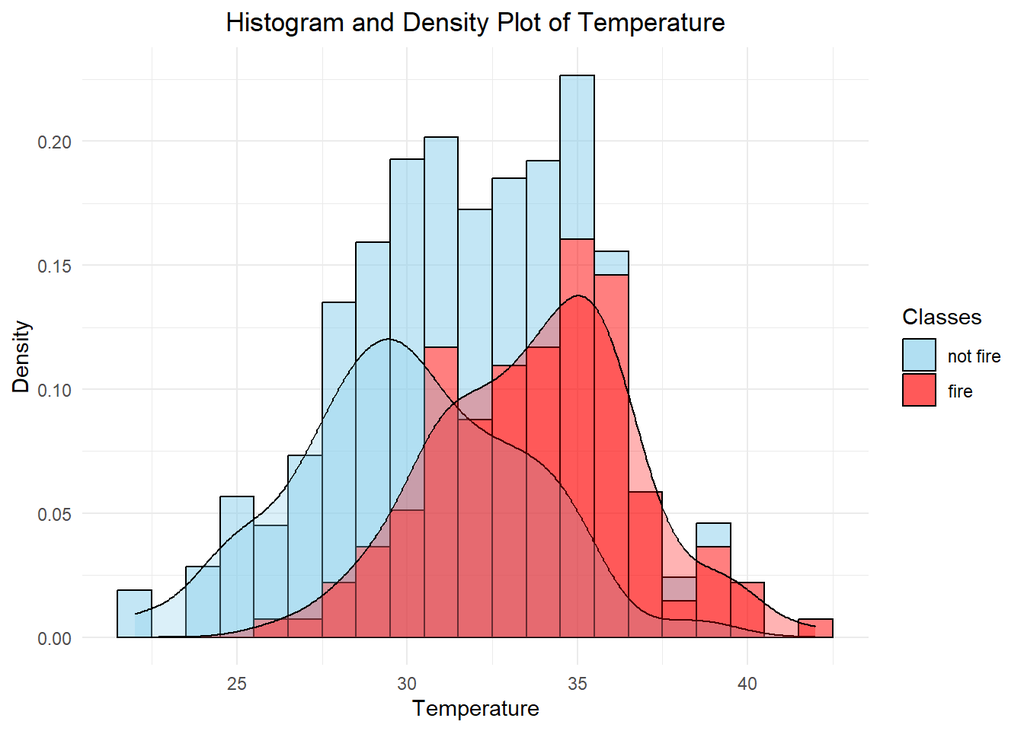

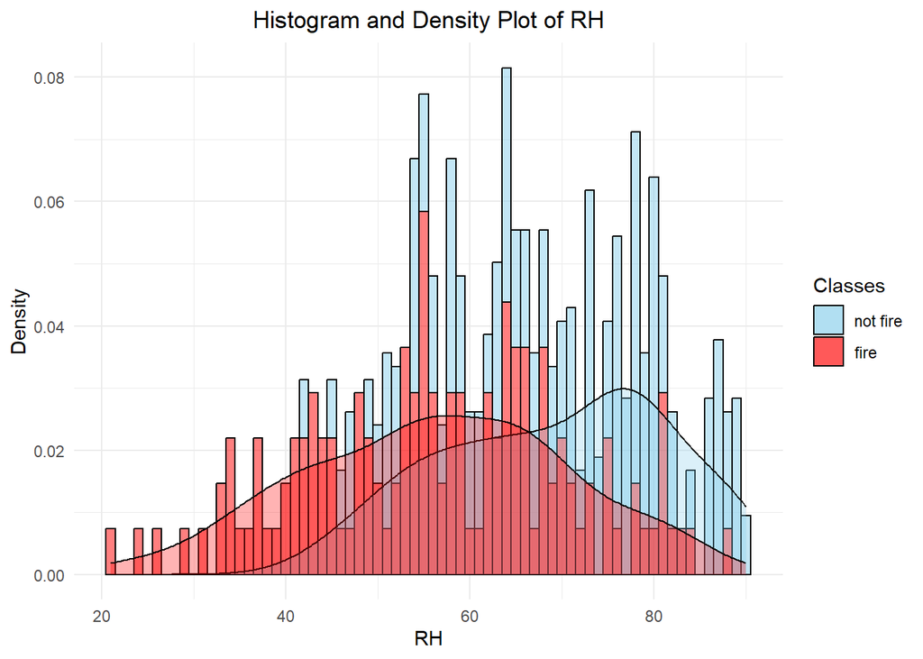

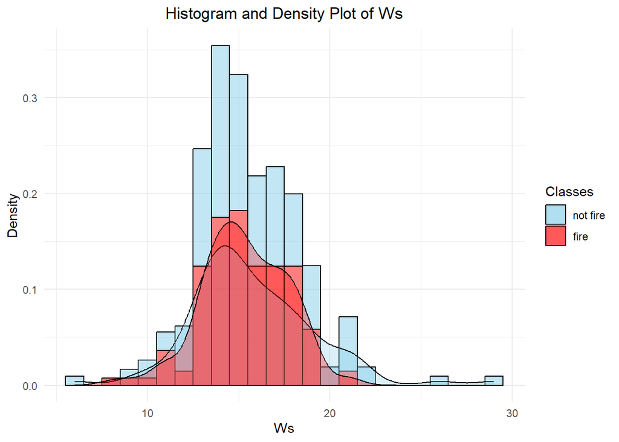

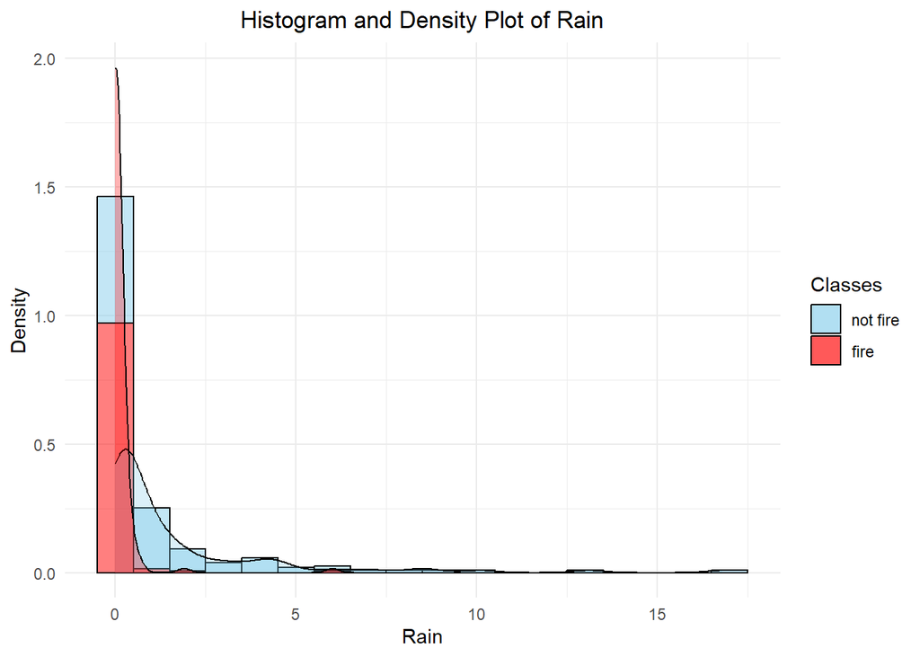

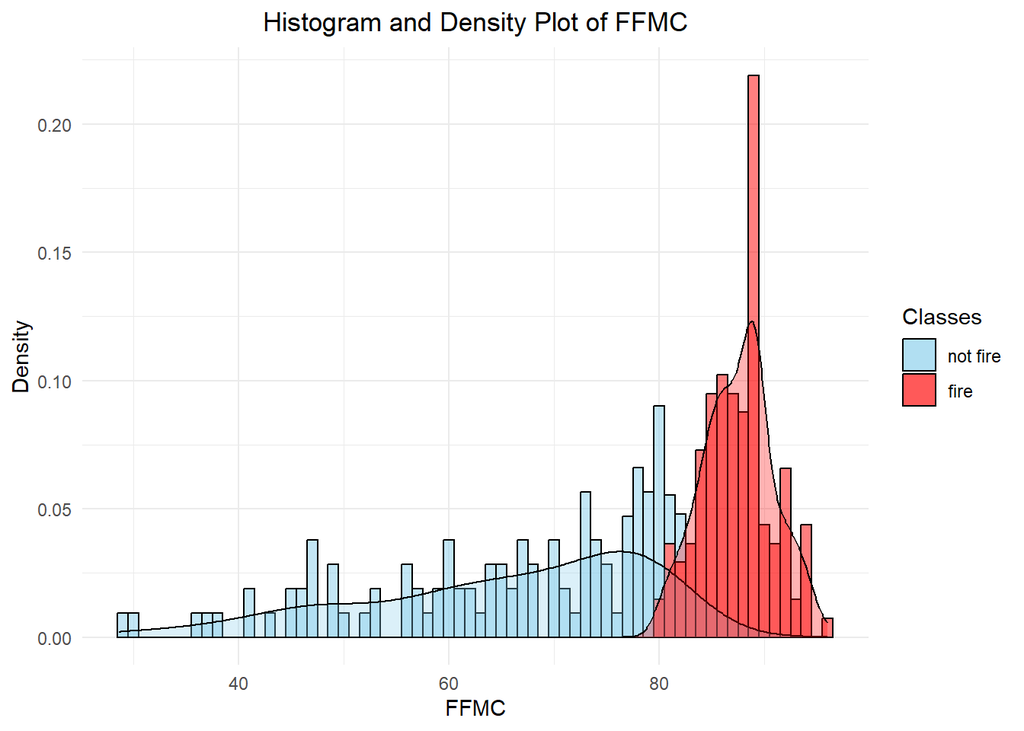

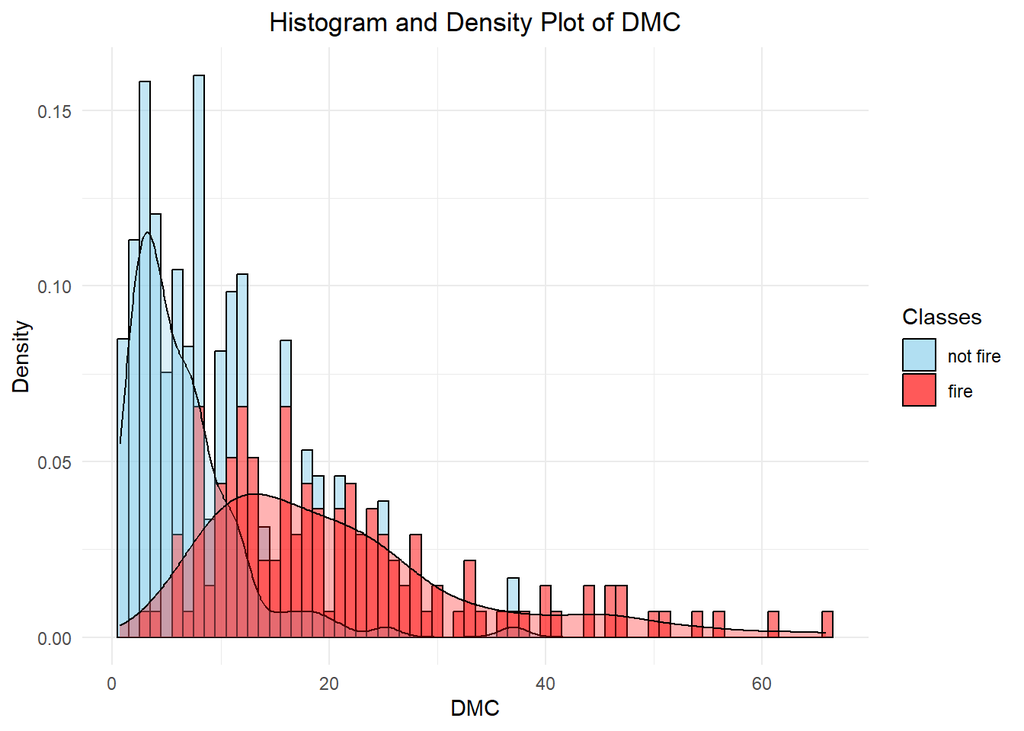

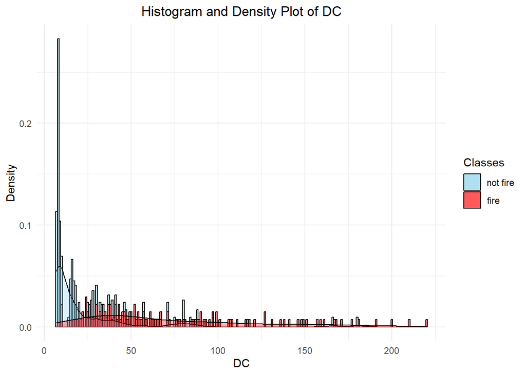

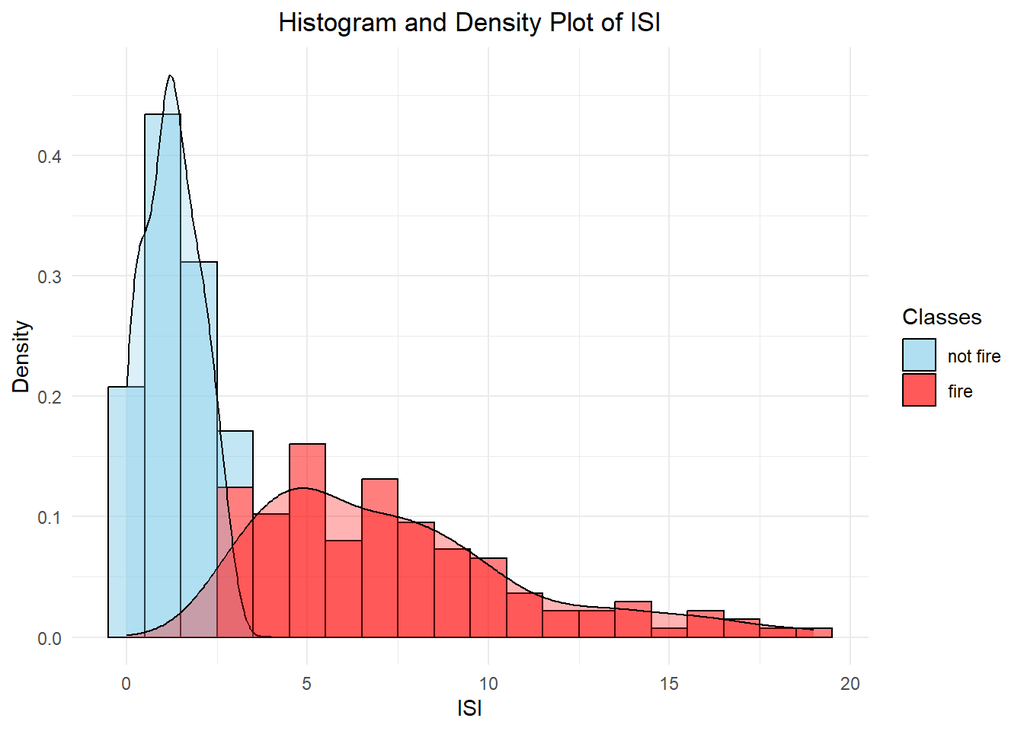

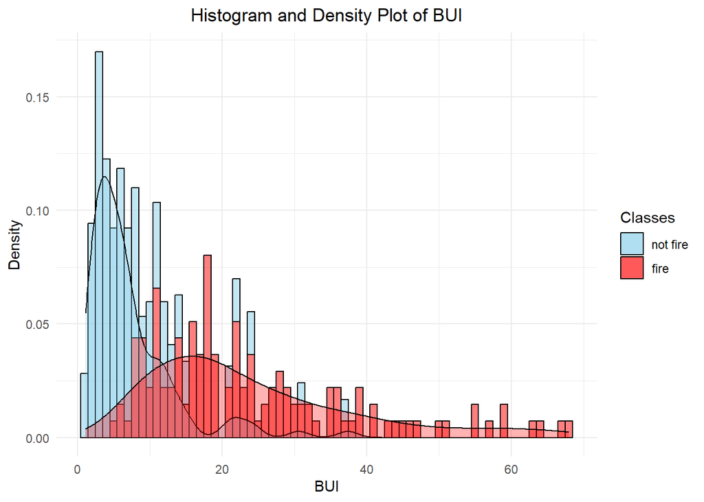

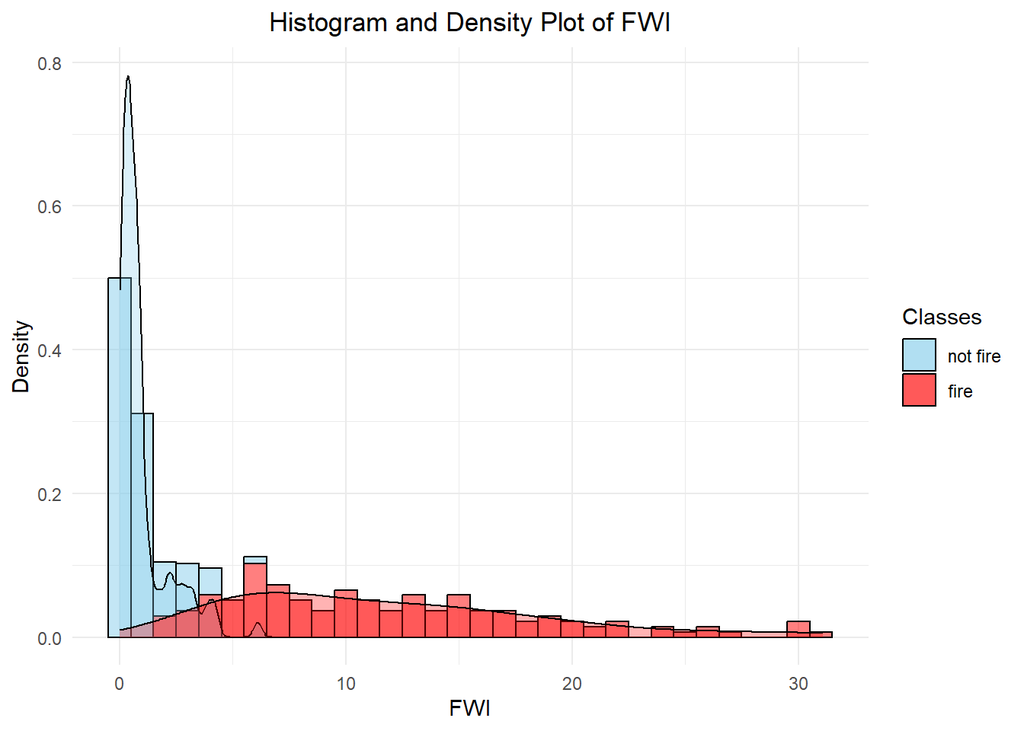

```r
## Visualizing numerical features

# Loop through each column and create plots
for (feature in numeric_columns) {
  # Combined Histogram and Density Plot
  p <- ggplot(final_data, aes(x = .data[[feature]], fill = Classes)) +  # Map Classes to fill color
    geom_histogram(aes(y = after_stat(density)), binwidth = 1, color = "black", alpha = 0.5) +
    geom_density(alpha = 0.3) +  # Density plot with transparent fill
    scale_fill_manual(values = c("fire" = "red", "not fire" = "skyblue")) +  # Manually set colors for Classes
    labs(title = paste("Histogram and Density Plot of", feature),
         x = feature,
         y = "Density") +
    theme_minimal() +
    theme(plot.title = element_text(hjust = 0.5))  # Center the title

  # Print the plot
  print(p)
}
```

The histogram and density plots reveal the relationships between various features and fire occurrence. *Temperature* shows that higher values (35°C and above) are strongly associated with fire, while lower temperatures correspond to non-fire instances. *RH* (Relative Humidity) inversely affects fire likelihood, with fires more common at lower humidity levels (below 50%). *Ws* has a moderate impact, with fires occurring more frequently at wind speeds around 10 to 15. *Rain* has a minimal effect, as most fires occur when rainfall is near zero. *FFMC* and *DMC* are crucial indicators, with higher values correlating strongly with fire, reflecting drier fuel and organic layers. Similarly, *DC* and *BUI* are significant; fires are more likely when these indices are high, indicating prolonged dryness and increased fuel accumulation. *ISI* and *FWI* are also critical, with higher values indicating faster fire spread and greater fire risk.

In conclusion, features like *FFMC*, *DMC*, *DC*, *BUI*, *ISI*, and *FWI* are the most important for distinguishing fire and non-fire instances due to their strong association with dry and combustible conditions. *Rain*, *Ws*, and *RH* are moderately important, while *Temperature*, though impactful, is less distinctive in isolation. This analysis highlights the critical role of dryness and fire indices in predicting fire occurrences.

### Box Plots

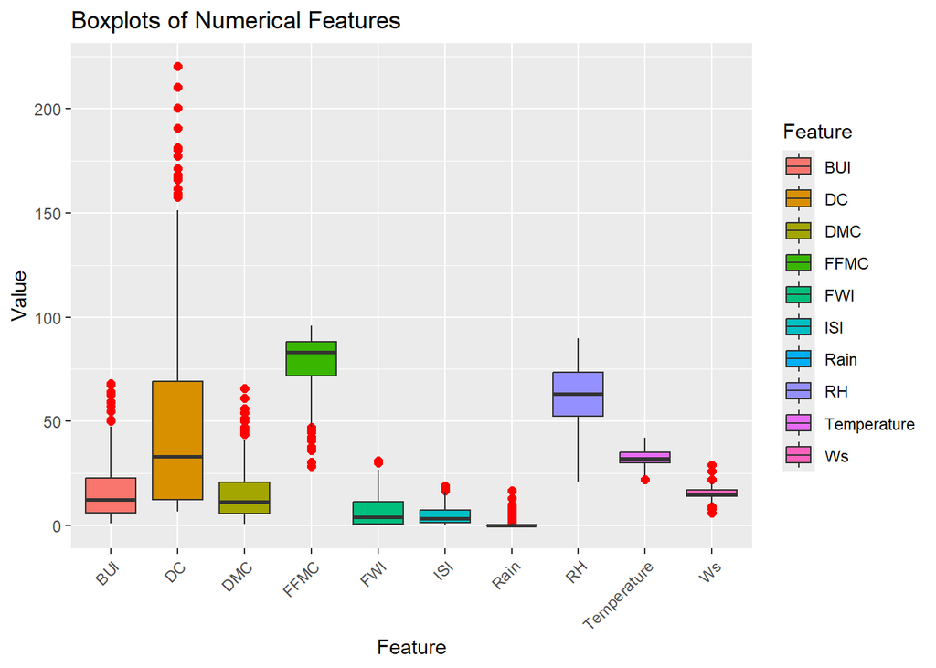

```r
# Boxplot for all numeric columns
final_data_long <- tidyr::pivot_longer(final_data, cols = numeric_columns, names_to = "Feature", values_to = "Value")

ggplot(final_data_long, aes(x = Feature, y = Value, fill = Feature)) +
  geom_boxplot(outlier.color = "red", outlier.size = 2) +
  theme(axis.text.x = element_text(angle = 45, hjust = 1)) +
  labs(title = "Boxplots of Numerical Features", x = "Feature", y = "Value")
```

### Pairs Plot

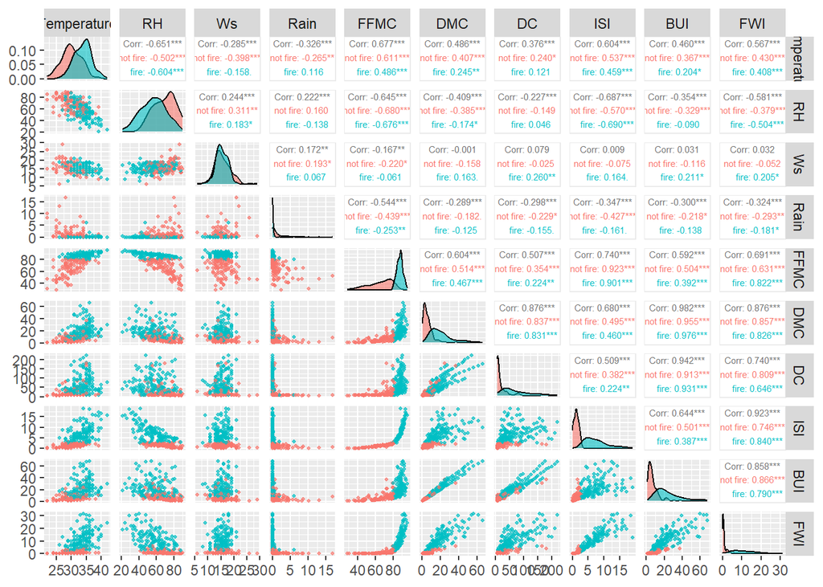

```r
ggpairs(
  final_data,
  columns = numeric_columns,  # Specify numeric columns
  aes(color = Classes),
  upper = list(
    continuous = wrap("cor", size = 2, align_percent = 0.5) # Text size for correlation labels
  ),
  lower = list(
    continuous = wrap("points", size = 0.75, alpha = 0.7)  # Scatter points size and transparency
  ),
  diag = list(
    continuous = wrap("densityDiag", alpha = 0.6)          # Adjust density plot transparency
  ),
  progress = FALSE                                          # Suppress progress bar
)
```

### Correlation matrix

```r
# Subset the data to include only the numeric columns and ClassesN
correlation_data <- final_data[, c(numeric_columns)]

# Compute the correlation matrix
correlation_matrix <- cor(correlation_data, use = "complete.obs")

# Display the correlation matrix
print(correlation_matrix)
```

```
##             Temperature         RH            Ws       Rain       FFMC
## Temperature   1.0000000 -0.6514003 -0.2845098897 -0.3264919  0.6765681
## RH           -0.6514003  1.0000000  0.2440483822  0.2223561 -0.6448735
## Ws           -0.2845099  0.2440484  1.0000000000  0.1715062 -0.1665483
## Rain         -0.3264919  0.2223561  0.1715061807  1.0000000 -0.5439062
## FFMC          0.6765681 -0.6448735 -0.1665482728 -0.5439062  1.0000000
## DMC           0.4856869 -0.4085192 -0.0007209737 -0.2887729  0.6036076
## DC            0.3762835 -0.2269411  0.0791345143 -0.2980231  0.5073967
## ISI           0.6038706 -0.6866670  0.0085316891 -0.3474839  0.7400068
## BUI           0.4597895 -0.3538405  0.0314384118 -0.2998515  0.5920110
## FWI           0.5666699 -0.5809567  0.0323677727 -0.3244216  0.6911320
##                       DMC          DC          ISI         BUI         FWI
## Temperature  0.4856869230  0.37628353  0.603870559  0.45978947  0.56666988
## RH          -0.4085191880 -0.22694112 -0.686667043 -0.35384055 -0.58095675
## Ws          -0.0007209737  0.07913451  0.008531689  0.03143841  0.03236777
## Rain        -0.2887729260 -0.29802308 -0.347483929 -0.29985152 -0.32442156
## FFMC         0.6036076410  0.50739666  0.740006828  0.59201101  0.69113197
## DMC          1.0000000000  0.87592466  0.680454326  0.98224849  0.87586416
## DC           0.8759246607  1.00000000  0.508643247  0.94198846  0.73952056
## ISI          0.6804543264  0.50864325  1.000000000  0.64409260  0.92289493
## BUI          0.9822484891  0.94198846  0.644092598  1.00000000  0.85797310
## FWI          0.8758641588  0.73952056  0.922894934  0.85797310  1.00000000
```

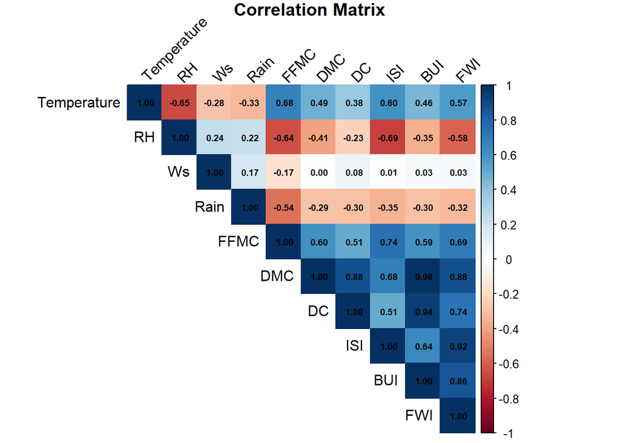

```r
# Plot the correlation matrix using corrplot
corrplot(correlation_matrix, method = "color", type = "upper",
         tl.col = "black", tl.srt = 45,
         addCoef.col = "black", number.cex = 0.6,
         title = "Correlation Matrix", mar = c(0, 0, 1, 0))
```

## Data Preprocessing

### Find the outliers in all features

```r
# Define numeric columns
n_columns <- c("Temperature", "Rain", "RH", "Ws", "FFMC", "DMC", "DC", "ISI", "BUI", "FWI")

# Function to find outliers using the IQR (INterquartile Range) method
find_outliers <- function(column) {
  Q1 <- quantile(column, 0.25)
  Q3 <- quantile(column, 0.75)
  IQR <- Q3 - Q1
  lower_bound <- Q1 - 1.5 * IQR
  upper_bound <- Q3 + 1.5 * IQR
  # Identify outliers that fall below the lower bound or above the upper bound
  outliers <- column[column < lower_bound | column > upper_bound]
  # If no outliers, return 0
  if (length(outliers) == 0) {
    return(0)
  } else {
    #Return a list containing the outliers and the bounds
    return(list(outliers = outliers, lower = lower_bound, upper = upper_bound))
  }
}

# Apply to numeric columns and print the results
for (col in numeric_columns) {
  outlier_info <- find_outliers(final_data[[col]])
  cat("\nThe outliers in", col, "are:\n")
  if (is.list(outlier_info)) {
    print(outlier_info$outliers)  # Print the outliers if a list is returned
  } else {
    print(outlier_info)  # Print 0 when no outliers are found
  }
}
```

```
##
## The outliers in Temperature are:
## [1] 22 22
##
## The outliers in RH are:
## [1] 0
##
## The outliers in Ws are:
## [1] 22 22 26  9  9  8  6 29
##
## The outliers in Rain are:
##  [1]  1.3 13.1  2.5  3.1  1.4 16.8  7.2 10.1  3.8  1.8  1.8  4.6  8.3  5.8  1.8
## [16]  1.4  4.0  2.0  1.3  2.0  4.7  8.7  4.5  1.7  2.2  6.0  1.9  3.8  2.9  3.1
## [31]  2.9  4.1  6.5  2.0  4.4
##
## The outliers in FFMC are:
##  [1] 47.1 28.6 36.1 37.3 46.0 30.5 42.6 40.9 44.9 45.0 37.9 41.1 45.9
##
## The outliers in DMC are:
##  [1] 43.9 45.6 47.0 50.2 54.2 44.2 46.6 46.1 51.3 56.3 61.3 65.9
##
## The outliers in DC are:
##  [1] 161.5 171.3 181.3 190.6 200.2 210.4 220.4 180.4 157.5 167.2 177.3 166.0
## [13] 159.1 168.2
##
## The outliers in ISI are:
## [1] 18.5 17.2 19.0 16.6
##
## The outliers in BUI are:
##  [1] 50.9 54.7 57.1 59.3 62.9 67.4 50.2 54.9 59.5 64.0 68.0
##
## The outliers in FWI are:
## [1] 30.2 30.0 31.1 30.3
```

The code identifies outliers in specified numeric features using the Interquartile Range (IQR) method. For each feature, the lower and upper bounds are calculated as Q1−1.5×IQR and Q3+1.5×IQR, respectively, and any data point outside this range is considered an outlier. The output lists outliers for each feature, highlighting features such as *Temperature*, *Ws*, *Rain*, *DMC*, and *DC*, which contain multiple outliers. These identified outliers could significantly impact the model’s performance if not handled appropriately, making this a critical preprocessing step.

### Perform Shapiro-Wilk test

```r
numeric_columns <- c("Temperature", "Rain", "FFMC", "DMC", "DC", "ISI", "BUI", "FWI")
for (col in numeric_columns) {
  shapiroWilk_test <- shapiro.test(final_data[[col]])
  cat("The Shapiro-Wilk Test for", col, ":\n")
  print(shapiroWilk_test)
}
```

```
## The Shapiro-Wilk Test for Temperature :
##
##  Shapiro-Wilk normality test
##
## data:  final_data[[col]]
## W = 0.98741, p-value = 0.03143
##
## The Shapiro-Wilk Test for Rain :
##
##  Shapiro-Wilk normality test
##
## data:  final_data[[col]]
## W = 0.42815, p-value < 2.2e-16
##
## The Shapiro-Wilk Test for FFMC :
##
##  Shapiro-Wilk normality test
##
## data:  final_data[[col]]
## W = 0.8506, p-value = 1.396e-14
##
## The Shapiro-Wilk Test for DMC :
##
##  Shapiro-Wilk normality test
##
## data:  final_data[[col]]
## W = 0.85901, p-value = 3.919e-14
##
## The Shapiro-Wilk Test for DC :
##
##  Shapiro-Wilk normality test
##
## data:  final_data[[col]]
## W = 0.81737, p-value = 3.396e-16
##
## The Shapiro-Wilk Test for ISI :
##
##  Shapiro-Wilk normality test
##
## data:  final_data[[col]]
## W = 0.88757, p-value = 1.864e-12
##
## The Shapiro-Wilk Test for BUI :
##
##  Shapiro-Wilk normality test
##
## data:  final_data[[col]]
## W = 0.85588, p-value = 2.658e-14
##
## The Shapiro-Wilk Test for FWI :
##
##  Shapiro-Wilk normality test
##
## data:  final_data[[col]]
## W = 0.85254, p-value = 1.764e-14
```

The Shapiro-Wilk test determines if features are normally distributed. For all the features, the p-value is < 0.05 which indicates non-normality for all numeric columns. Since none of the features passed the normality test, it’s safer to proceed with normalization rather than standardization.

### Feature Selection using Random Forests

To optimize our machine learning models and enhance their predictive accuracy, we’ll be employing a Random Forest algorithm to perform feature selection. Random Forests are particularly effective for this purpose because they provide a built-in mechanism for ranking the importance of features based on how well they improve the model’s performance.

By focusing on the most impactful features, we can streamline our model, reduce overfitting, and potentially enhance computational efficiency.

```r
# Train the Random Forest model
model <- randomForest(Classes ~ .-ClassesN, data = final_data, importance = TRUE)

# Get feature importance
importance <- importance(model)
print(importance)
```

```
##               not fire       fire MeanDecreaseAccuracy MeanDecreaseGini
## month        3.6755194 -1.9448034            1.2647482       0.58308914
## Temperature  1.6249097  2.9091301            3.2960932       1.60058677
## RH           1.9639239  3.9509078            4.2672170       1.31421942
## Ws           2.1244501 -0.2857142            1.0264490       0.41234006
## Rain         2.6937056  5.6225935            6.3343821       4.37433734
## FFMC        15.7252809 20.5067453           22.3628904      32.78503306
## DMC          4.4328825  4.9659498            6.3881800       7.53460558
## DC           4.9347990  5.6155726            7.3220499       6.38387146
## ISI         18.1176761 21.8872731           24.7652862      34.07663019
## BUI          4.3771472  5.5325257            7.3397892       7.86491683
## FWI         11.0856594 13.5072583           16.5012051      21.75005331
## Location    -2.0062466  2.1742102            1.5999580       0.09432036
## day_group    0.1198471  0.8370550            0.6624435       0.35016110
```

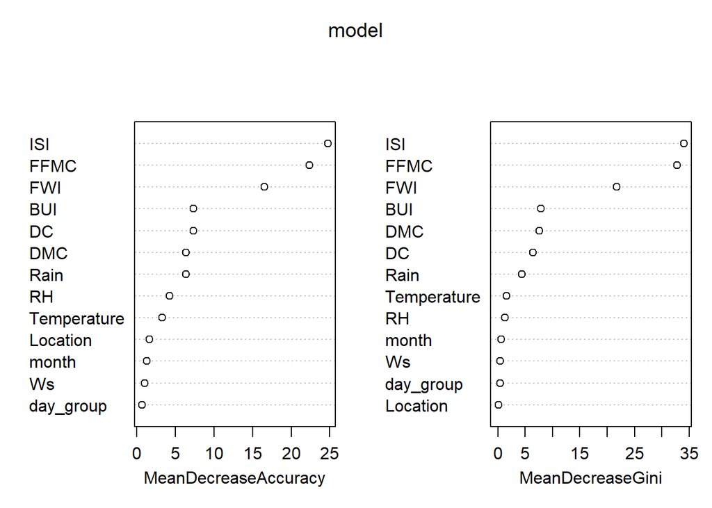

```r
# Visualize feature importance
varImpPlot(model)
```

The feature importance analysis of the Random Forest model reveals that *ISI* (Initial Spread Index) and *FFMC* (Fine Fuel Moisture Code) are the most influential features, significantly impacting both the model’s accuracy (Mean Decrease Accuracy) and its ability to split the data effectively (Mean Decrease Gini). Features like *FWI* (Fire Weather Index), *DC* (Drought Code), and *DMC* (Duff Moisture Code) also contribute meaningfully to the model’s performance. On the other hand, features such as *Location*, *Ws* (Wind Speed), and *day_group* demonstrate minimal importance, showing little effect on the model’s predictive accuracy or splitting ability. This emphasizes the importance of fire-related indices in the dataset for accurately predicting the target variable.

### Feature Selection using Recursive Feature Elimination

After identifying key predictors through initial feature importance analysis, we proceeded to validate and refine our feature selection using Recursive Feature Elimination (RFE). This technique is particularly effective for pinpointing the most predictive features within a dataset, ensuring our model focuses on the most impactful variables.

**Implementation of RFE**

Using the `caret` package’s RFE functionality, we configured the process to utilize cross-validation, specifically a 10-fold cross-validation, to evaluate the performance decrement when excluding each feature. This method helps in robustly determining the feature set that maximizes predictive accuracy by iteratively removing less important features and re-evaluating the model.

```r
control <- rfeControl(functions = rfFuncs, method = "cv", number = 10)
rfe_results <- rfe(final_data[, -which(names(final_data) == "Classes" | names(final_data) == "ClassesN")],
                   final_data$Classes,
                   sizes = c(1:ncol(final_data)-1),
                   rfeControl = control)
print(rfe_results)
```

```
##
## Recursive feature selection
##
## Outer resampling method: Cross-Validated (10 fold)
##
## Resampling performance over subset size:
##
##  Variables Accuracy  Kappa AccuracySD KappaSD Selected
##          0   0.9678 0.9347    0.03680 0.07413
##          1   0.9678 0.9347    0.03680 0.07413
##          2   0.9840 0.9675    0.02797 0.05676
##          3   0.9840 0.9672    0.02797 0.05758
##          4   0.9880 0.9756    0.01932 0.03934        *
##          5   0.9840 0.9672    0.02797 0.05758
##          6   0.9840 0.9672    0.02797 0.05758
##          7   0.9840 0.9672    0.02797 0.05758
##          8   0.9840 0.9672    0.02797 0.05758
##          9   0.9840 0.9672    0.02797 0.05758
##         10   0.9840 0.9672    0.02797 0.05758
##         11   0.9797 0.9585    0.02858 0.05868
##         12   0.9800 0.9593    0.03399 0.06907
##         13   0.9800 0.9593    0.03399 0.06907
##
## The top 4 variables (out of 4):
##    ISI, FFMC, FWI, DC
```

```r
# Retrieve the subset of features that gave the best performance
optimal_features <- predictors(rfe_results)
print(optimal_features)
```

```
## [1] "ISI"  "FFMC" "FWI"  "DC"
```

The Recursive Feature Elimination (RFE) process validated *ISI* (Initial Spread Index) and *FFMC* (Fine Fuel Moisture Code) as the most impactful features for predicting fire events. This finding aligns with our earlier analysis using random forest feature importance, highlighting the consistency in feature significance across different methodologies.

# Model Development

## Spliting the dataset

The dataset was split into: Training set with 70% of the data. Testing set with 30% of the data.

```r
# Set a seed for reproducibility
set.seed(101)

# Assuming your dataset is named 'data'
# Step 1: Split 70% for training and 30% for testing
split <- sample.split(final_data$Classes, SplitRatio = 0.7)
train <- subset(final_data, split == TRUE)
test <- subset(final_data, split == FALSE)
```

To address the issue of outliers in our dataset, we evaluated two potential strategies:

1. **Removing Outliers**: This approach involves identifying and excluding extreme values from the dataset. However, given the relatively small size of our dataset, removing outliers could result in a significant loss of data, potentially skewing the results and reducing the statistical power of subsequent analyses. Therefore, we decided against this method.
2. **Winsorization**: Instead, we opted for Winsorization, a method that limits extreme values in the dataset without deleting any data points. This technique modifies the outliers by replacing them with the nearest values at the specified percentiles, in this case, the 5th and 95th percentiles. Winsorization is promising because it retains all data points while reducing the influence of outliers, making it particularly suitable for our dataset size and the potential impact of extreme values.

Given these considerations, we proceeded to apply Winsorization to the training set first, to assess its effectiveness before potentially applying it to other parts of the dataset.

```r
# Winsorize numeric columns in the training data
# Applying Winsorization at the 5th and 95th percentiles
train_winsorized <- train

# Apply Winsorization to each numeric column using the correct 'range' argument
train_winsorized[numeric_columns] <- lapply(train_winsorized[numeric_columns], function(x) {
  Winsorize(x, val = quantile(x, probs = c(0.05, 0.95), na.rm = FALSE))
})

# Check the effect of Winsorization
summary(train_winsorized)
```

```
##  month   Temperature          RH              Ws             Rain
##  6:35   Min.   :25.45   Min.   :24.00   Min.   : 6.00   Min.   :0.0000
##  7:46   1st Qu.:29.25   1st Qu.:53.00   1st Qu.:14.00   1st Qu.:0.0000
##  8:46   Median :32.00   Median :64.00   Median :15.00   Median :0.0000
##  9:43   Mean   :32.09   Mean   :62.62   Mean   :15.62   Mean   :0.5682
##         3rd Qu.:35.00   3rd Qu.:75.00   3rd Qu.:17.00   3rd Qu.:0.4000
##         Max.   :38.00   Max.   :90.00   Max.   :26.00   Max.   :4.5550
##       FFMC            DMC               DC              ISI
##  Min.   :47.23   Min.   : 1.900   Min.   :  7.60   Min.   : 0.300
##  1st Qu.:70.62   1st Qu.: 5.275   1st Qu.: 15.25   1st Qu.: 1.400
##  Median :82.95   Median :11.350   Median : 33.25   Median : 3.600
##  Mean   :78.32   Mean   :14.764   Mean   : 50.69   Mean   : 4.798
##  3rd Qu.:88.53   3rd Qu.:22.275   3rd Qu.: 75.17   3rd Qu.: 7.475
##  Max.   :92.36   Max.   :43.305   Max.   :158.38   Max.   :14.020
##       BUI              FWI             Classes         Location
##  Min.   : 2.490   Min.   : 0.100   not fire:74   Cordillera:88
##  1st Qu.: 5.825   1st Qu.: 0.700   fire    :96   Hudson Bay:82
##  Median :12.450   Median : 4.150
##  Mean   :16.929   Mean   : 7.109
##  3rd Qu.:23.900   3rd Qu.:12.900
##  Max.   :48.985   Max.   :21.985
##     ClassesN      day_group
##  Min.   :0.0000   Early:56
##  1st Qu.:0.0000   Mid  :56
##  Median :1.0000   Late :58
##  Mean   :0.5647
##  3rd Qu.:1.0000
##  Max.   :1.0000
```

## Normalization of Training and Testing Sets

Normalization is a critical preprocessing step in data analysis, particularly when preparing data for machine learning models. By normalizing the data, we ensure that each feature contributes equally to the analysis, preventing variables with larger scales from disproportionately influencing the model’s behavior. This step involves adjusting the scale of the data so that different measurements are directly comparable and model training is stable and faster.

In this process, we first normalize the training set, establishing a reference scale based on its distribution. We then apply the same scaling factors to the test set. This approach ensures that both datasets are on the same scale, maintaining consistency in how models interpret the features across both training and testing phases. Using the training set statistics (minimum and maximum values) for normalizing the test set prevents information leakage and ensures that our model evaluations are realistic and unbiased.

This methodology not only aligns with best practices in data preparation but also enhances the predictive performance and interpretability of the models developed from this data.

```r
# Define a normalization function
normalize <- function(column) {
  # The normalization equation:
  # x' = (x - min(x)) / (max(x) - min(x))
  return((column - min(column)) / (max(column) - min(column)))
}

# Normalize the training set
train_normalized <- train
numeric_columns <- names(train)[sapply(train, is.numeric)]  # Identify numeric columns dynamically
train_normalized[numeric_columns] <- lapply(train_normalized[numeric_columns], normalize)

# Store min and max for each numeric column from the training set
min_values <- sapply(train [numeric_columns], min)
max_values <- sapply(train [numeric_columns], max)

# Function to normalize using train stats
normalize_using_train_stats <- function(column, min_val, max_val) {
  (column - min_val) / (max_val - min_val)
}

# Normalize the test set using training set statistics
test_normalized <- test
test_normalized[numeric_columns] <- Map(normalize_using_train_stats,
                                        test[numeric_columns],
                                        min_values,
                                        max_values)

# View the normalized data
head(train_normalized)
```

```
##   month Temperature        RH   Ws       Rain      FFMC         DMC          DC
## 1     6        0.35 0.5000000 0.60 0.00000000 0.5504451 0.041411043 0.003439803
## 2     6        0.35 0.5606061 0.35 0.09923664 0.5311573 0.052147239 0.003439803
## 3     6        0.20 0.8787879 0.80 1.00000000 0.2744807 0.027607362 0.000982801
## 4     6        0.15 0.9848485 0.35 0.19083969 0.0000000 0.009202454 0.000000000
## 5     6        0.25 0.8030303 0.50 0.00000000 0.5370920 0.035276074 0.035872236
## 6     6        0.45 0.6515152 0.40 0.00000000 0.8011869 0.078220859 0.075184275
##          ISI        BUI         FWI  Classes   Location ClassesN day_group
## 1 0.06842105 0.03437967 0.016077170 not fire Cordillera        0     Early
## 2 0.05263158 0.04185351 0.012861736 not fire Cordillera        0     Early
## 3 0.01578947 0.02391629 0.003215434 not fire Cordillera        0     Early
## 4 0.00000000 0.00896861 0.000000000 not fire Cordillera        0     Early
## 5 0.06315789 0.04185351 0.016077170 not fire Cordillera        0     Early
## 6 0.16315789 0.08819133 0.080385852     fire Cordillera        1     Early
```

```r
head(test_normalized)
```

```
##    month Temperature        RH   Ws        Rain      FFMC        DMC
## 8      6        0.40 0.7424242 0.45 0.000000000 0.8605341 0.17484663
## 11     6        0.45 0.6212121 0.40 0.000000000 0.8293769 0.18098160
## 16     6        0.35 0.9848485 0.35 0.053435115 0.1112760 0.01533742
## 18     6        0.45 0.8181818 0.40 0.022900763 0.4198813 0.01840491
## 19     6        0.45 0.4696970 0.50 0.007633588 0.7611276 0.05828221
## 24     6        0.50 0.6363636 0.55 0.000000000 0.8501484 0.16104294
##             DC        ISI        BUI         FWI  Classes   Location ClassesN
## 8  0.154299754 0.29473684 0.18535127 0.228295820     fire Cordillera        1
## 11 0.232923833 0.21052632 0.21973094 0.180064309     fire Cordillera        1
## 16 0.003439803 0.00000000 0.01644245 0.000000000 not fire Cordillera        0
## 18 0.005405405 0.03684211 0.01943199 0.006430868 not fire Cordillera        0
## 19 0.044717445 0.13157895 0.06278027 0.045016077 not fire Cordillera        0
## 24 0.240294840 0.29473684 0.20627803 0.241157556     fire Cordillera        1
##    day_group
## 8      Early
## 11       Mid
## 16       Mid
## 18       Mid
## 19       Mid
## 24      Late
```

To evaluate the effectiveness of Winsorization alongside our standard preprocessing, we will also normalize the Winsorized data, ensuring it is suitably scaled for subsequent analysis.

```r
# Normalize the winsorized training set
train_normalized_w <- train_winsorized
numeric_columns <- names(train)[sapply(train, is.numeric)]  # Identify numeric columns dynamically
train_normalized_w[numeric_columns] <- lapply(train_normalized_w[numeric_columns], normalize)

# Store min and max for each numeric column from the training set
min_values_w <- sapply(train_winsorized [numeric_columns], min)
max_values_w <- sapply(train_winsorized [numeric_columns], max)

# Normalize the test set using training set statistics
test_normalized_w <- test
test_normalized_w[numeric_columns] <- Map(normalize_using_train_stats,
                                        test[numeric_columns],
                                        min_values_w,
                                        max_values_w)

# View the winsorised normalized data
head(train_normalized_w)
```

```
##   month Temperature        RH   Ws      Rain      FFMC        DMC         DC
## 1     6   0.2828685 0.5000000 0.60 0.0000000 0.4091513 0.03622751 0.00000000
## 2     6   0.2828685 0.5606061 0.35 0.2854007 0.3803457 0.05313368 0.00000000
## 3     6   0.0438247 0.8787879 0.80 1.0000000 0.0000000 0.01449100 0.00000000
## 4     6   0.0000000 0.9848485 0.35 0.5488474 0.0000000 0.00000000 0.00000000
## 5     6   0.1235060 0.8030303 0.50 0.0000000 0.3892090 0.02656684 0.04377238
## 6     6   0.4422311 0.6515152 0.40 0.0000000 0.7836251 0.09419152 0.09682982
##          ISI         BUI        FWI  Classes   Location ClassesN day_group
## 1 0.07288630 0.019571997 0.01827736 not fire Cordillera        0     Early
## 2 0.05102041 0.030325841 0.01370802 not fire Cordillera        0     Early
## 3 0.00000000 0.004516615 0.00000000 not fire Cordillera        0     Early
## 4 0.00000000 0.000000000 0.00000000 not fire Cordillera        0     Early
## 5 0.06559767 0.030325841 0.01827736 not fire Cordillera        0     Early
## 6 0.20408163 0.096999677 0.10966415     fire Cordillera        1     Early
```

```r
head(test_normalized_w)
```

```
##    month Temperature        RH   Ws       Rain       FFMC          DMC
## 8      6   0.3625498 0.7424242 0.45 0.00000000  0.8722579  0.246347060
## 11     6   0.4422311 0.6212121 0.40 0.00000000  0.8257257  0.256007729
## 16     6   0.2828685 0.9848485 0.35 0.15367728 -0.2467317 -0.004830335
## 18     6   0.4422311 0.8181818 0.40 0.06586169  0.2141591  0.000000000
## 19     6   0.4422311 0.4696970 0.50 0.02195390  0.7237979  0.062794349
## 24     6   0.5219124 0.6363636 0.55 0.00000000  0.8567472  0.224610554
##             DC         ISI          BUI         FWI  Classes   Location
## 8  0.203607906  0.38629738  0.236799656  0.31985378     fire Cordillera
## 11 0.309722775  0.26967930  0.286267341  0.25131369     fire Cordillera
## 16 0.000000000 -0.02186589 -0.006237230 -0.00456934 not fire Cordillera
## 18 0.002652872  0.02915452 -0.001935692  0.00456934 not fire Cordillera
## 19 0.055710306  0.16034985  0.060436606  0.05940142 not fire Cordillera
## 24 0.319671044  0.38629738  0.266910420  0.33813114     fire Cordillera
##    ClassesN day_group
## 8         1     Early
## 11        1       Mid
## 16        0       Mid
## 18        0       Mid
## 19        0       Mid
## 24        1      Late
```

## Logistic Regression

```r
# Train logistic regression model on the training set
logistic_model <- glm(Classes ~ .-ClassesN -Location -month -day_group -Ws, data = train_normalized, family = binomial())

# Summarize the model
summary(logistic_model)
```

```
##
## Call:
## glm(formula = Classes ~ . - ClassesN - Location - month - day_group -
##     Ws, family = binomial(), data = train_normalized)
##
## Coefficients:
##               Estimate Std. Error z value Pr(>|z|)
## (Intercept)   -1707.30  347608.73  -0.005    0.996
## Temperature    -365.97   55527.24  -0.007    0.995
## RH               82.02   30037.81   0.003    0.998
## Rain           1018.03  386975.05   0.003    0.998
## FFMC           1822.86  455699.10   0.004    0.997
## DMC           -1891.05 1403554.30  -0.001    0.999
## DC             -429.68  579919.02  -0.001    0.999
## ISI            3203.31  816078.24   0.004    0.997
## BUI            3267.38 1963722.39   0.002    0.999
## FWI           -2734.33  837893.80  -0.003    0.997
##
## (Dispersion parameter for binomial family taken to be 1)
##
##     Null deviance: 2.3281e+02  on 169  degrees of freedom
## Residual deviance: 1.4128e-07  on 160  degrees of freedom
## AIC: 20
##
## Number of Fisher Scoring iterations: 25
```

The logistic regression model summary reveals extremely large coefficients with very high standard errors and statistically insignificant p-values (close to 1) across all predictor variables. These outcomes suggest that the model may be suffering from multicollinearity, poor scaling, or overfitting issues.

**Analysis of Logistic Regression Output**:

- **Coefficients**: The extreme values in the coefficients suggest that the model may be highly sensitive to slight changes in the input data. Such high coefficients typically indicate issues with the data scale or variance inflation due to correlated predictors.
- **Standard Errors**: The large standard errors reflect instability in the estimation of coefficients, which can result from multicollinearity among predictors or outliers in the data affecting the regression line fit.
- **Z-values and P-values**: The near-zero z-values and high p-values (close to 1) for all predictors indicate that none of the coefficients are statistically significant at conventional levels, implying that we fail to reject the null hypothesis for each predictor. This could mean that the predictors do not have a significant impact on the model or the model is not well specified.
- **Deviance**: The residual deviance close to zero suggests that the model fits the data almost perfectly, which could be a sign of overfitting, especially when paired with an extremely high number of Fisher Scoring iterations (25 in this case).

```r
# Initialize 'models' as a data frame to store the actual classes and their numeric representations from the test set
# This setup allows us to systematically store and access various model outputs such as predicted probabilities and class labels.
models <- data.frame(
  Classes = test_normalized$Classes,   # Actual classes from the test set
  ClassesN = test_normalized$ClassesN  # Numeric representations of the classes
)
# We will append model predictions and other metrics to this data frame to keep results organized and easily accessible.


# Predict probabilities on the test set
models$LR_predicted_prob <- predict(logistic_model, newdata = test_normalized, type = "response")

# Convert probabilities to binary class prediction based on a threshold (default 0.5)
models$LR_predicted_class <- ifelse(models$LR_predicted_prob > 0.5, "fire", "not fire")
models$LR_predicted_class <- factor(models$LR_predicted_class, levels = c("not fire", "fire"))
# Confusion matrix to see the accuracy of the model
conf_matrix_LR <- confusionMatrix(factor(models$LR_predicted_class), factor(models$Classes))

# Print the confusion matrix
print(conf_matrix_LR)
```

```
## Confusion Matrix and Statistics
##
##           Reference
## Prediction not fire fire
##   not fire       29    3
##   fire            3   38
##
##                Accuracy : 0.9178
##                  95% CI : (0.8296, 0.9692)
##     No Information Rate : 0.5616
##     P-Value [Acc > NIR] : 2.222e-11
##
##                   Kappa : 0.8331
##
##  Mcnemar's Test P-Value : 1
##
##             Sensitivity : 0.9062
##             Specificity : 0.9268
##          Pos Pred Value : 0.9062
##          Neg Pred Value : 0.9268
##              Prevalence : 0.4384
##          Detection Rate : 0.3973
##    Detection Prevalence : 0.4384
##       Balanced Accuracy : 0.9165
##
##        'Positive' Class : not fire
##
```

```r
# Print overall model accuracy from the confusion matrix
print(paste("Accuracy:", conf_matrix_LR$overall['Accuracy']))
```

```
## [1] "Accuracy: 0.917808219178082"
```

**Model Fit and Predictive Performance**:

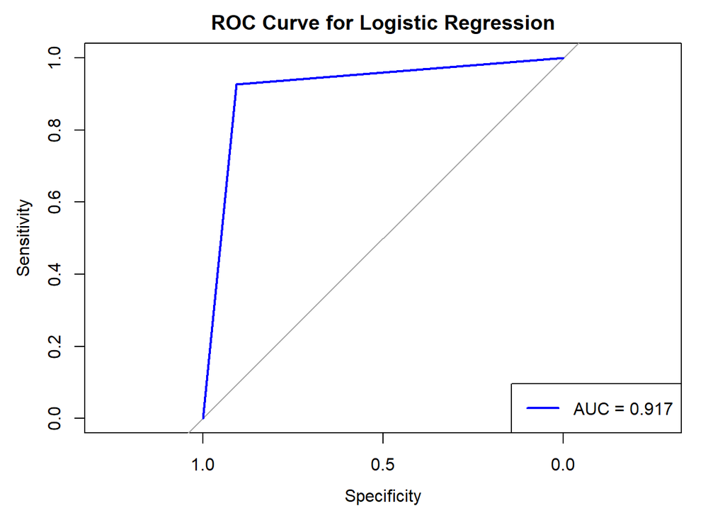

```r
# ROC curve for the test set
roc_result <- roc(response = test_normalized$Classes, predictor = as.numeric(models$LR_predicted_class))

# Compute AUC for the logistic regression
logistic_auc <- auc(roc_result)

# Plot ROC curve
plot(roc_result, main = "ROC Curve for Logistic Regression",col = "blue", lwd = 2)
legend("bottomright", legend = paste("AUC =", round(logistic_auc, 3)), col = "blue", lwd = 2)
```

- **AUC**: The Area Under the Curve (AUC) of 0.917 also indicates excellent model performance.

```r
# Initialize a data frame to store performance metrics
performance_metrics <- data.frame(
  Sensitivity = numeric(),
  Specificity = numeric(),
  Pos_Predictive_Value = numeric(),
  Neg_Predictive_Value = numeric(),
  Prevalence = numeric(),
  Detection_Rate = numeric(),
  Detection_Prevalence = numeric(),
  Balanced_Accuracy = numeric(),
  AUC = numeric(),
  row.names = character(),
  stringsAsFactors = FALSE
)

# Extract metrics from confusion matrix
logistic_metrics <- conf_matrix_LR$byClass

# Append logistic regression results to the performance metrics table
performance_metrics["Logistic Regression", ] <- c(
  Sensitivity = logistic_metrics['Sensitivity'],
  Specificity = logistic_metrics['Specificity'],
  Positive_Predictive_Value = logistic_metrics['Pos Pred Value'],
  Negative_Predictive_Value = logistic_metrics['Neg Pred Value'],
  Prevalence = mean(test_normalized$Classes == "fire"),
  Detection_Rate = logistic_metrics['Detection Rate'],
  Detection_Prevalence = logistic_metrics['Detection Prevalence'],
  Balanced_Accuracy = logistic_metrics['Balanced Accuracy'],
  AUC = logistic_auc
)
```

### LR with Optimal Features

After observing suboptimal performance with a broader set of features in the logistic regression model, we refine our approach by focusing on the two features previously identified as most impactful: *ISI* (Initial Spread Index) and *FFMC* (Fine Fuel Moisture Code). This targeted approach aims to enhance model accuracy and interpretability by utilizing only the key predictors validated through feature selection techniques.

```r
# Train logistic regression model on the training set
logistic_model <- glm(Classes ~ ISI + FFMC, data = train_normalized, family = binomial())

# Summarize the model
summary(logistic_model)
```

```
##
## Call:
## glm(formula = Classes ~ ISI + FFMC, family = binomial(), data = train_normalized)
##
## Coefficients:
##             Estimate Std. Error z value Pr(>|z|)
## (Intercept)   -34.92      39.41  -0.886   0.3756
## ISI           110.85      59.70   1.857   0.0634 .
## FFMC           24.26      56.67   0.428   0.6686
## ---
## Signif. codes:  0 '***' 0.001 '**' 0.01 '*' 0.05 '.' 0.1 ' ' 1
##
## (Dispersion parameter for binomial family taken to be 1)
##
##     Null deviance: 232.815  on 169  degrees of freedom
## Residual deviance:  13.505  on 167  degrees of freedom
## AIC: 19.505
##
## Number of Fisher Scoring iterations: 11
```

```r
# Predict probabilities on the test set
models$LR_predicted_prob_opt <- predict(logistic_model, newdata = test_normalized, type = "response")

# Convert probabilities to binary class prediction based on a threshold (default 0.5)
models$LR_predicted_class_opt <- ifelse(models$LR_predicted_prob_opt > 0.5, "fire", "not fire")
models$LR_predicted_class_opt <- factor(models$LR_predicted_class_opt, levels = c("not fire", "fire"))
# Confusion matrix to see the accuracy of the model
conf_matrix <- confusionMatrix(factor(models$LR_predicted_class_opt), factor(models$Classes))

# Print the confusion matrix
print(conf_matrix)
```

```
## Confusion Matrix and Statistics
##
##           Reference
## Prediction not fire fire
##   not fire       32    1
##   fire            0   40
##
##                Accuracy : 0.9863
##                  95% CI : (0.926, 0.9997)
##     No Information Rate : 0.5616
##     P-Value [Acc > NIR] : <2e-16
##
##                   Kappa : 0.9723
##
##  Mcnemar's Test P-Value : 1
##
##             Sensitivity : 1.0000
##             Specificity : 0.9756
##          Pos Pred Value : 0.9697
##          Neg Pred Value : 1.0000
##              Prevalence : 0.4384
##          Detection Rate : 0.4384
##    Detection Prevalence : 0.4521
##       Balanced Accuracy : 0.9878
##
##        'Positive' Class : not fire
##
```

```r
# Print overall model accuracy from the confusion matrix
print(paste("Accuracy:", conf_matrix$overall['Accuracy']))
```

```
## [1] "Accuracy: 0.986301369863014"
```

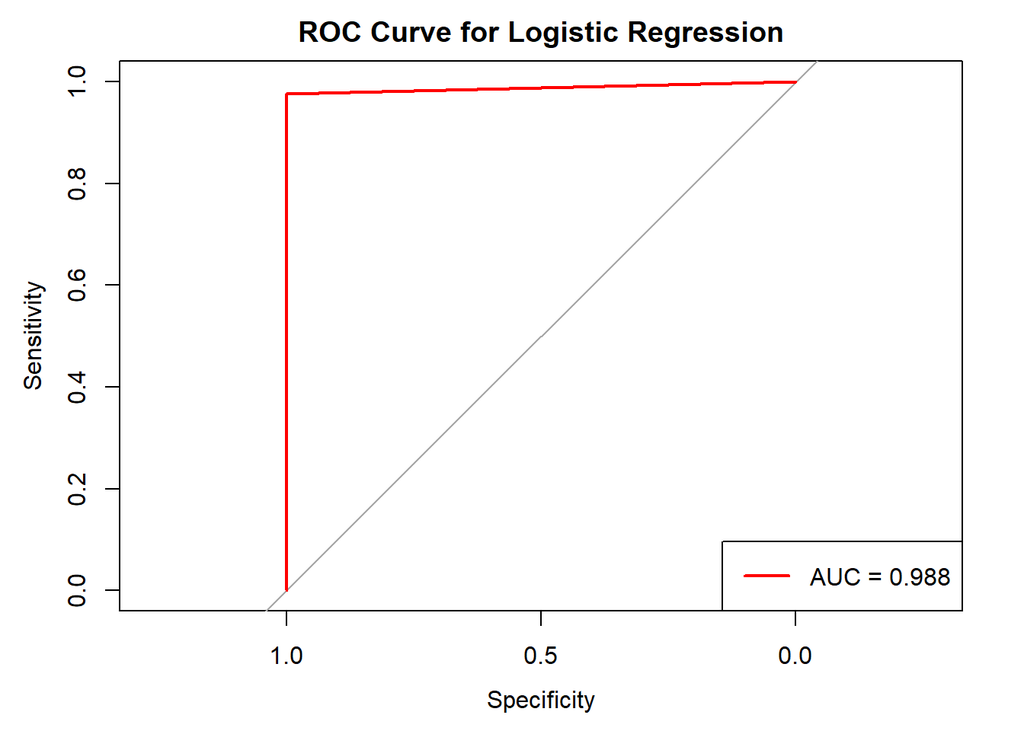

```r
# ROC curve for the test set
roc_result <- roc(response = test_normalized$Classes, predictor = as.numeric(models$LR_predicted_class_opt))

# Plot ROC curve
plot(roc_result, main = "ROC Curve for Logistic Regression",col = "red", lwd = 2)
legend("bottomright", legend = paste("AUC =", round(auc(roc_result), 3)), col = "red", lwd = 2)
```

The refined logistic regression model using *ISI* and *FFMC* as predictors demonstrates excellent predictive performance:

- **Coefficients**: The model indicates that both *ISI* (p=0.0634) and *FFMC* (p=0.6686) contribute to predictions, with *ISI* showing a stronger and near-significant influence on the likelihood of fire occurrences.
- **Fit and Accuracy**: The model achieves a high accuracy of 98.63%, with a residual deviance significantly lower than the null deviance, showcasing its effective fit to the data.
- **Statistical Measures**:
- **AIC**: The low Akaike Information Criterion (AIC) score suggests a good fit relative to the number of predictors.
- **Kappa**: A Kappa statistic of 0.9723 indicates almost perfect agreement.
- **AUC**: An AUC of 0.988 confirms the model’s superior ability to discriminate between the presence and absence of fire.

### LR with Winsorization

Now, we are going to evaluate the performance of our logistic regression model using winsorized data with the optimal features, *ISI* and *FFMC*.

```r
# Train logistic regression model on the training set
logistic_model <- glm(Classes ~ ISI + FFMC, data = train_normalized_w, family = binomial())

# Summarize the model
summary(logistic_model)
```

```
##
## Call:
## glm(formula = Classes ~ ISI + FFMC, family = binomial(), data = train_normalized_w)
##
## Coefficients:
##             Estimate Std. Error z value Pr(>|z|)
## (Intercept)   -26.46      24.48  -1.081   0.2797
## ISI            80.04      43.11   1.857   0.0634 .
## FFMC           16.25      37.95   0.428   0.6686
## ---
## Signif. codes:  0 '***' 0.001 '**' 0.01 '*' 0.05 '.' 0.1 ' ' 1
##
## (Dispersion parameter for binomial family taken to be 1)
##
##     Null deviance: 232.815  on 169  degrees of freedom
## Residual deviance:  13.505  on 167  degrees of freedom
## AIC: 19.505
##
## Number of Fisher Scoring iterations: 11
```

```r
# Predict probabilities on the test set
models$LR_predicted_prob_w <- predict(logistic_model, newdata = test_normalized, type = "response")

# Convert probabilities to binary class prediction based on a threshold (default 0.5)
models$LR_predicted_class_w <- ifelse(models$LR_predicted_prob_w > 0.5, "fire", "not fire")
models$LR_predicted_class_w <- factor(models$LR_predicted_class_w, levels = c("not fire", "fire"))
# Confusion matrix to see the accuracy of the model
conf_matrix <- confusionMatrix(factor(models$LR_predicted_class_w), factor(models$Classes))

# Print the confusion matrix
print(conf_matrix)
```

```
## Confusion Matrix and Statistics
##
##           Reference
## Prediction not fire fire
##   not fire       32    5
##   fire            0   36
##
##                Accuracy : 0.9315
##                  95% CI : (0.8474, 0.9774)
##     No Information Rate : 0.5616
##     P-Value [Acc > NIR] : 2.458e-12
##
##                   Kappa : 0.8632
##
##  Mcnemar's Test P-Value : 0.07364
##
##             Sensitivity : 1.0000
##             Specificity : 0.8780
##          Pos Pred Value : 0.8649
##          Neg Pred Value : 1.0000
##              Prevalence : 0.4384
##          Detection Rate : 0.4384
##    Detection Prevalence : 0.5068
##       Balanced Accuracy : 0.9390
##
##        'Positive' Class : not fire
##
```

```r
# Print overall model accuracy from the confusion matrix
print(paste("Accuracy:", conf_matrix$overall['Accuracy']))
```

```
## [1] "Accuracy: 0.931506849315068"
```

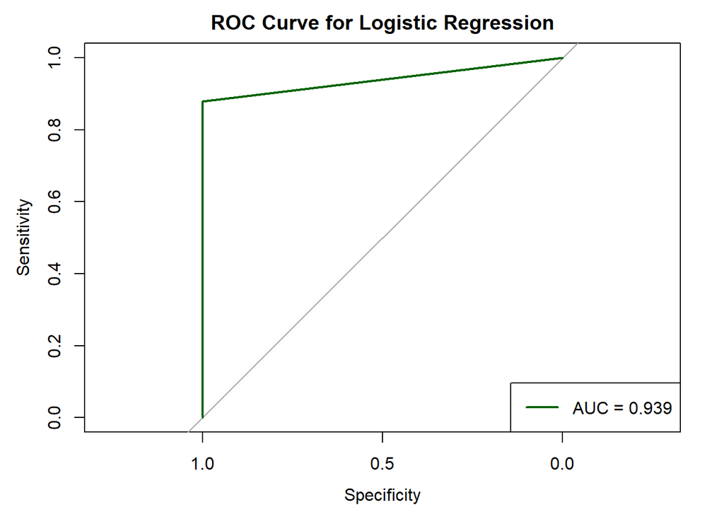

```r
# ROC curve for the test set
roc_result <- roc(response = test_normalized$Classes, predictor = as.numeric(models$LR_predicted_class_w))

# Plot ROC curve
plot(roc_result, main = "ROC Curve for Logistic Regression",col = "darkgreen", lwd = 2)
legend("bottomright", legend = paste("AUC =", round(auc(roc_result), 3)), col = "darkgreen", lwd = 2)
```

This logistic regression model offers a different perspective on the robustness of our predictive approach:

- **Model Coefficients**: The model’s intercept and coefficients for *ISI* and *FFMC* have changed slightly compared to the non-winsorized data. The intercept has shifted to -26.46 from -34.92, and the coefficients for *ISI* and *FFMC* have decreased, reflecting the impact of limiting extreme values on the model’s parameter estimates.
- **Comparative Performance**: Despite these adjustments, the model shows a decline in performance metrics compared to the non-winsorized version. The accuracy has decreased from 98.63% to 93.15%, and the AUC has slightly dropped from 0.988 to 0.939. These changes suggest that winsorization may not be beneficial for this dataset in enhancing model accuracy.

Further testing of winsorization across other models consistently resulted in similar or reduced effectiveness. Based on these outcomes, we have opted not to use winsorization as a preprocessing method for our analysis. The presence of outliers appears to be less detrimental than the effects of limiting data variability through winsorization.

> In subsequent modeling efforts, we broadened our feature selection beyond just *ISI* and *FFMC*, the two features previously identified as the most influential. This decision was driven by a desire to avoid overly reducing our feature set, particularly given the relatively small size of our dataset.

> To determine the most relevant features for inclusion, we revisited insights from the Random Forest importance measures, Recursive Feature Elimination (RFE) results, and the patterns observed during Exploratory Data Analysis (EDA). From this comprehensive review, we chose to include the following features in our models: *Temperature*, *RH*, *Rain*, *FFMC*, *DMC*, *DC*, *ISI*, *BUI*, and *FWI*. This selection was made despite a slight increase in performance metrics observed when using only *ISI* and *FFMC*. Features like *ClassesN*, *Location*, *day_group*, *month*, and *Ws* were excluded based on their lower significance and impact in predictive modeling as indicated by our preliminary analyses.

> This approach allows us to maintain a robust set of predictors that are substantiated by multiple analytical methods, ensuring a well-rounded and scientifically grounded model development process.

## LDA

```r
# Apply LDA to the training data
lda_model <- lda(Classes ~ .-ClassesN -Location -day_group -month -Ws, data = train_normalized)

# Summary of the model
summary(lda_model)
```

```
##         Length Class  Mode
## prior    2     -none- numeric
## counts   2     -none- numeric
## means   18     -none- numeric
## scaling  9     -none- numeric
## lev      2     -none- character
## svd      1     -none- numeric
## N        1     -none- numeric
## call     3     -none- call
## terms    3     terms  call
## xlevels  3     -none- list
```

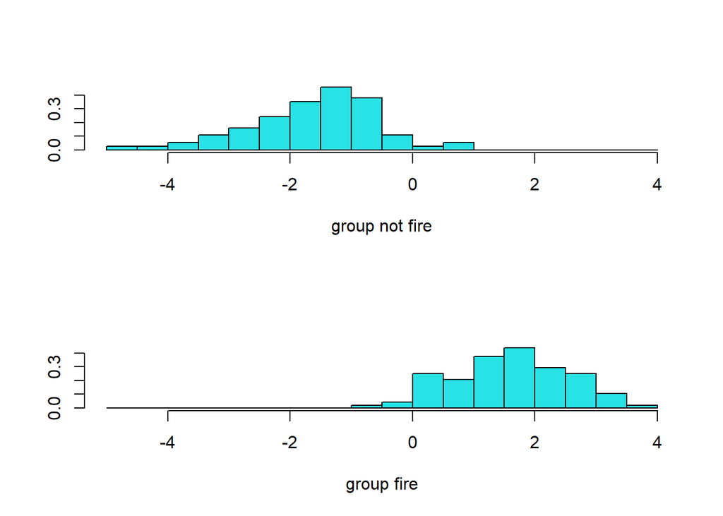

```r
# Plotting the LDA model
plot(lda_model)
```

```r
# Predicting on the test set
lda_predictions <- predict(lda_model, newdata = test_normalized)

# Accessing the class predictions
models$lda_predicted_class <- lda_predictions$class

# Confusion Matrix to evaluate the model
conf_matrix_LDA <- confusionMatrix(data = models$lda_predicted_class, reference = test_normalized$Classes)

print(conf_matrix_LDA)
```

```
## Confusion Matrix and Statistics
##
##           Reference
## Prediction not fire fire
##   not fire       30    6
##   fire            2   35
##
##                Accuracy : 0.8904
##                  95% CI : (0.7954, 0.9515)
##     No Information Rate : 0.5616
##     P-Value [Acc > NIR] : 1.121e-09
##
##                   Kappa : 0.7805
##
##  Mcnemar's Test P-Value : 0.2888
##
##             Sensitivity : 0.9375
##             Specificity : 0.8537
##          Pos Pred Value : 0.8333
##          Neg Pred Value : 0.9459
##              Prevalence : 0.4384
##          Detection Rate : 0.4110
##    Detection Prevalence : 0.4932
##       Balanced Accuracy : 0.8956
##
##        'Positive' Class : not fire
##
```

The LDA model applied to predict fire occurrences achieved an accuracy of 89.04% with a 95% confidence interval of (0.7954, 0.9515),and a Kappa statistic of 0.7805, indicating good agreement beyond chance. It effectively balanced sensitivity (93.75%) and specificity (85.37%), resulting in a balanced accuracy of 89.56%. The model’s positive predictive value of 83.33% and negative predictive value of 94.59% demonstrate its reliability in classifying both ‘fire’ and ‘not fire’ scenarios.

The discriminant score histograms for the ‘not fire’ and ‘fire’ groups show clear differentiation between the classes, though some overlap explains the few misclassifications observed. This slight overlap resulted in six ‘fire’ cases predicted as ‘not fire’ and two ‘not fire’ cases as ‘fire’.

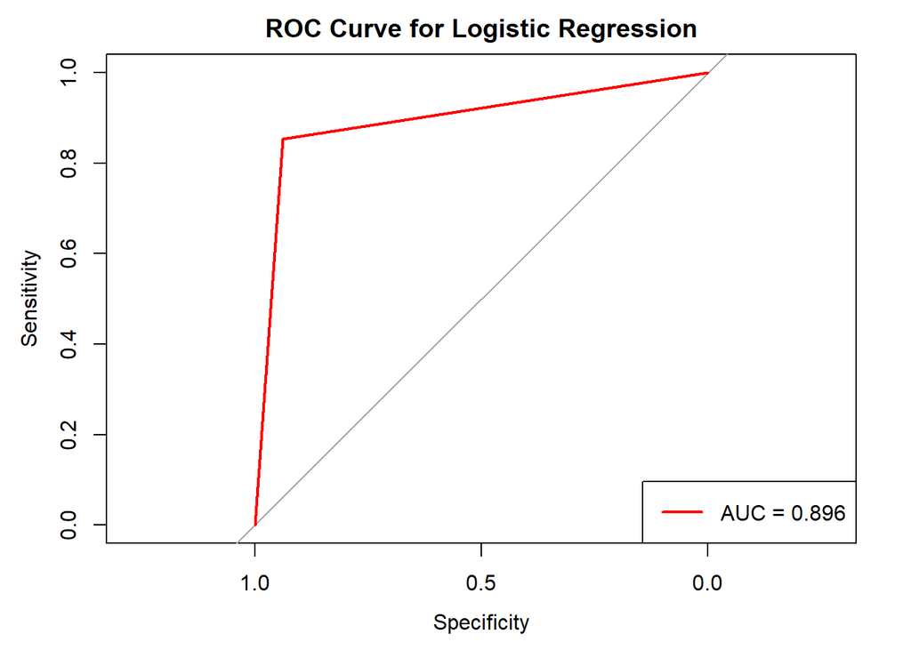

```r
# ROC curve for the test set
roc_result <- roc(response = test_normalized$Classes, predictor = as.numeric(models$lda_predicted_class))

lda_auc <- auc(roc_result)

# Plot ROC curve
plot(roc_result, main = "ROC Curve for Logistic Regression",col = "red", lwd = 2)
legend("bottomright", legend = paste("AUC =", round(lda_auc, 3)), col = "red", lwd = 2)
```

The Linear Discriminant Analysis model yielded an AUC of 0.896, signifying strong capability in distinguishing between the classes ‘fire’ and ‘not fire’ across various threshold settings. While this indicates excellent predictive accuracy, there is still potential for improvement to achieve even higher performance.

```r
lda_metrics <- conf_matrix_LDA$byClass

# Append LDA results to the performance metrics table
performance_metrics["Linear Discriminant Analysis", ] <-c(
  Sensitivity = lda_metrics['Sensitivity'],
  Specificity = lda_metrics['Specificity'],
  Positive_Predictive_Value = lda_metrics['Pos Pred Value'],
  Negative_Predictive_Value = lda_metrics['Neg Pred Value'],
  Prevalence = mean(test_normalized$Classes == "fire"),
  Detection_Rate = lda_metrics['Detection Rate'],
  Detection_Prevalence = lda_metrics['Detection Prevalence'],
  Balanced_Accuracy = lda_metrics['Balanced Accuracy'],
  AUC = lda_auc
)
```

## QDA

```r
# Apply QDA to the training data
qda_model <- qda(Classes ~ .-ClassesN -Location -day_group -month -Ws, data = train_normalized)

# Summary of the model
summary(qda_model)
```

```
##         Length Class  Mode
## prior     2    -none- numeric
## counts    2    -none- numeric
## means    18    -none- numeric
## scaling 162    -none- numeric
## ldet      2    -none- numeric
## lev       2    -none- character
## N         1    -none- numeric
## call      3    -none- call
## terms     3    terms  call
## xlevels   3    -none- list
```

```r
# Predicting on the test set
qda_predictions <- predict(qda_model, newdata = test_normalized)

# Accessing the class predictions
models$qda_predicted_class <- qda_predictions$class

# Confusion Matrix to evaluate the model
conf_matrix_QDA <- confusionMatrix(data = models$qda_predicted_class, reference = test_normalized$Classes)

print(conf_matrix_QDA)
```

```
## Confusion Matrix and Statistics
##
##           Reference
## Prediction not fire fire
##   not fire       30    0
##   fire            2   41
##
##                Accuracy : 0.9726
##                  95% CI : (0.9045, 0.9967)
##     No Information Rate : 0.5616
##     P-Value [Acc > NIR] : 8.52e-16
##
##                   Kappa : 0.944
##
##  Mcnemar's Test P-Value : 0.4795
##
##             Sensitivity : 0.9375
##             Specificity : 1.0000
##          Pos Pred Value : 1.0000
##          Neg Pred Value : 0.9535
##              Prevalence : 0.4384
##          Detection Rate : 0.4110
##    Detection Prevalence : 0.4110
##       Balanced Accuracy : 0.9688
##
##        'Positive' Class : not fire
##
```

In the analysis using Quadratic Discriminant Analysis (QDA), the model achieved an impressive accuracy of 97.26%, with a perfect specificity of 100% for the ‘fire’ class and a high sensitivity of 93.75% for the ‘not fire’ class. This high level of specificity indicates no false positives were predicted for ‘fire’, demonstrating the model’s precision.

The confusion matrix further illustrates the model’s robust predictive power, successfully identifying all ‘fire’ cases without error and accurately classifying ‘not fire’ instances with a positive predictive value of 100%. The negative predictive value stood at 95.35%, affirming the model’s reliability. Additionally, the balanced accuracy was calculated at 96.88%, and the Kappa statistic was 0.944, indicating almost perfect agreement beyond chance between the model’s predictions and the actual class labels.

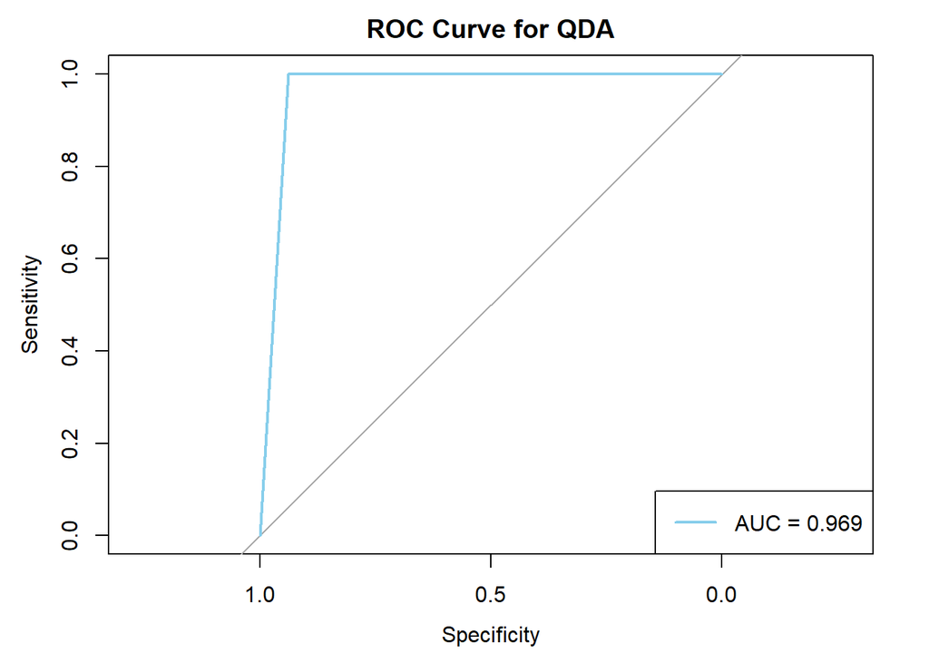

```r
# ROC curve for the QDA test set predictions
roc_result_qda <- roc(response = test_normalized$Classes, predictor = as.numeric(models$qda_predicted_class == "fire"))

qda_auc <- auc(roc_result_qda)

# Plot ROC curve for QDA
plot(roc_result_qda, main = "ROC Curve for QDA",col = "skyblue", lwd = 2)
legend("bottomright", legend = paste("AUC =", round(qda_auc, 3)), col = "skyblue", lwd = 2)
```

Furthermore, the model’s Area Under the Curve (AUC) of 0.969 indicates excellent capability in discriminating between the classes across all thresholds. This performance slightly surpasses that of the Linear Discriminant Analysis (LDA) previously conducted, highlighting QDA’s potential advantages in managing more complex relationships through its quadratic decision boundaries.

```r
qda_metrics <- conf_matrix_QDA$byClass

# Append QDA results to the performance metrics table
performance_metrics["Quadratic Discriminant Analysis", ] <- c(
  Sensitivity = qda_metrics['Sensitivity'],
  Specificity = qda_metrics['Specificity'],
  Positive_Predictive_Value = qda_metrics['Pos Pred Value'],
  Negative_Predictive_Value = qda_metrics['Neg Pred Value'],
  Prevalence = mean(test_normalized$Classes == "fire"),
  Detection_Rate = qda_metrics['Detection Rate'],
  Detection_Prevalence = qda_metrics['Detection Prevalence'],
  Balanced_Accuracy = qda_metrics['Balanced Accuracy'],
  AUC = qda_auc
)
```

## KNN

```r
# Extract target variable (Classes)
train_target <- train_normalized$Classes
test_target <- test_normalized$Classes

# Exclude both 'Classes' (target) and 'ClassesN' from features
train_features <- train_normalized[, setdiff(colnames(train_normalized), c("Classes", "ClassesN", "Ws"))]
test_features <- test_normalized[, setdiff(colnames(test_normalized), c("Classes", "ClassesN", "Ws"))]

# Ensure features are numeric
train_features <- train_features[, sapply(train_features, is.numeric)]
test_features <- test_features[, sapply(test_features, is.numeric)]

# Define a range of k values
k_values <- seq(2, 30)  # Adjust as needed
accuracy <- numeric(length(k_values))

# Perform KNN for each k
for (i in seq_along(k_values)) {
  k <- k_values[i]
  # Predict using KNN
  predictions <- knn(train_features, test_features, train_target, k = k)
  # Calculate accuracy
  accuracy[i] <- sum(predictions == test_target) / length(test_target)
}

# Create a data frame for results
results <- data.frame(k = k_values, Accuracy = accuracy)

print(results)
```

```
##     k  Accuracy
## 1   2 0.8904110
## 2   3 0.9726027
## 3   4 0.9589041
## 4   5 0.9589041
## 5   6 0.9315068
## 6   7 0.9178082
## 7   8 0.9178082
## 8   9 0.9178082
## 9  10 0.9041096
## 10 11 0.9178082
## 11 12 0.9178082
## 12 13 0.9041096
## 13 14 0.9041096
## 14 15 0.9041096
## 15 16 0.9041096
## 16 17 0.9041096
## 17 18 0.9178082
## 18 19 0.9178082
## 19 20 0.9178082
## 20 21 0.9041096
## 21 22 0.9178082
## 22 23 0.9178082
## 23 24 0.9315068
## 24 25 0.9178082
## 25 26 0.9452055
## 26 27 0.9178082
## 27 28 0.9178082
## 28 29 0.9178082
## 29 30 0.9178082
```

This code evaluates the performance of the K-Nearest Neighbors (KNN) algorithm by varying the number of neighbors (k) and calculating the accuracy for each k on a test dataset. The results show that accuracy peaks at k = 3, reaching 0.9726 (97.26%), indicating this is the optimal choice for balancing model complexity and performance. At lower values of k, such as k=2, the model is more prone to overfitting, as shown by a lower accuracy (0.8904). As k increases beyond 3, the accuracy stabilizes around 91.78%, with slight fluctuations, and drops slightly at k=10 to 0.9041, likely due to underfitting. This behavior reflects the trade-off between overfitting and underfitting as k changes.

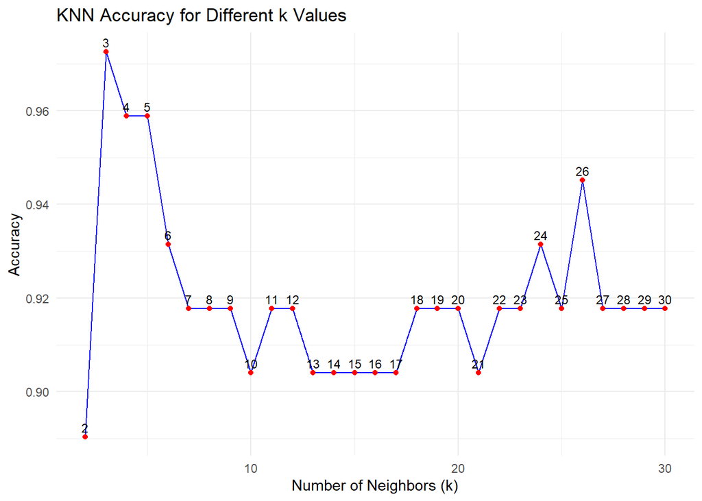

```r
# Plotting accuracy for each value of k
ggplot(results, aes(x = k, y = Accuracy)) +
  geom_line(color = "blue") +
  geom_point(color = "red") +
  geom_text(aes(label = k), vjust = -0.5, size = 3) +  # Annotate k-values
  labs(title = "KNN Accuracy for Different k Values",
       x = "Number of Neighbors (k)",
       y = "Accuracy") +
  theme_minimal()
```

The plot visualizes the relationship between the number of neighbors (k) and the accuracy of the KNN model. The visual representation helps confirm that k=3 is optimal for this dataset, as it maximizes accuracy while avoiding performance degradation.

```r
# Example for confusion matrix using the best k
best_k <- k_values[which.max(accuracy)]  # Select the best k
cat("The best value of k is:", best_k, "\n\n")
```

```
## The best value of k is: 3
```

```r
models$knn_predictions <- knn(train_features, test_features, train_target, k = best_k)  # Predict using best k

# Convert test target to a factor
test_target_factor <- factor(test_target, levels = unique(test_target))

# Confusion matrix
conf_matrix_KNN <- confusionMatrix(factor(models$knn_predictions, levels = levels(test_target_factor)), test_target_factor)
print(conf_matrix_KNN)
```

```
## Confusion Matrix and Statistics
##
##           Reference
## Prediction fire not fire
##   fire       40        1
##   not fire    1       31
##
##                Accuracy : 0.9726
##                  95% CI : (0.9045, 0.9967)
##     No Information Rate : 0.5616
##     P-Value [Acc > NIR] : 8.52e-16
##
##                   Kappa : 0.9444
##
##  Mcnemar's Test P-Value : 1
##
##             Sensitivity : 0.9756
##             Specificity : 0.9688
##          Pos Pred Value : 0.9756
##          Neg Pred Value : 0.9688
##              Prevalence : 0.5616
##          Detection Rate : 0.5479
##    Detection Prevalence : 0.5616
##       Balanced Accuracy : 0.9722
##
##        'Positive' Class : fire
##
```

The confusion matrix and associated statistics evaluate the KNN model with the best k=3. The model achieves an accuracy of 97.26% with a 95% confidence interval of (0.9045, 0.9967), indicating high reliability in its predictions. The sensitivity (true positive rate) is 97.56%, meaning the model accurately detects “fire” cases most of the time, while the specificity (true negative rate) is 96.88%, reflecting accurate identification of “not fire” cases. The high Kappa statistic (0.9444) further confirms strong agreement between predictions and actual labels. Positive and negative predictive values are also high, at 97.56% and 96.88%, respectively, showing the model’s reliability in making correct classifications. The balanced accuracy, which averages sensitivity and specificity, is 97.22%, reinforcing the model’s overall effectiveness.

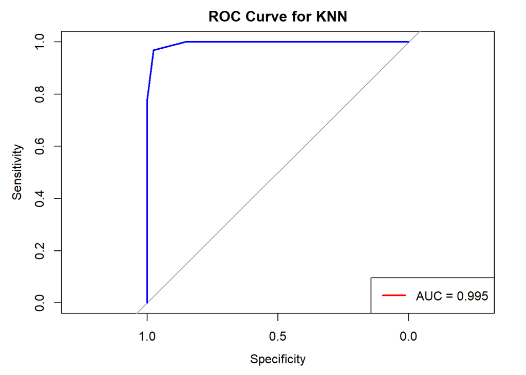

```r
# Compute probabilities for the positive class
knn_probabilities <- knn(train_features, test_features, train_target, k = best_k, prob = TRUE)
prob_positive <- attr(knn_probabilities, "prob")  # Get probabilities for the majority class

# Adjust probabilities for binary classification
prob_positive <- ifelse(knn_probabilities == levels(test_target_factor)[1], 1 - prob_positive, prob_positive)

# Plot the ROC curve
roc_curve <- roc(test_target_factor, prob_positive)
# Find AUC value
auc_KNN <- auc(roc_curve)

plot(roc_curve, col = "blue", main = "ROC Curve for KNN")
legend("bottomright", legend = paste("AUC =", round(auc_KNN, 3)), col = "red", lwd = 2)
```

The ROC curve for the KNN model shows excellent classification performance, with an AUC of 0.995, which is very close to the ideal value of 1. This indicates that the model is highly effective at distinguishing between positive and negative classes, with minimal overlap or misclassification. The steep rise of the curve towards the top-left corner reflects high sensitivity (true positive rate - TPR) and specificity (true negative rate) across varying thresholds.

```r
KNN_metrics <- conf_matrix_KNN$byClass

# Append KNN results to the performance metrics table
performance_metrics["KNN", ] <- c(
  Sensitivity = KNN_metrics['Sensitivity'],
  Specificity = KNN_metrics['Specificity'],
  Positive_Predictive_Value = KNN_metrics['Pos Pred Value'],
  Negative_Predictive_Value = KNN_metrics['Neg Pred Value'],
  Prevalence = mean(test_normalized$Classes == "fire"),
  Detection_Rate = KNN_metrics['Detection Rate'],
  Detection_Prevalence = KNN_metrics['Detection Prevalence'],
  Balanced_Accuracy = KNN_metrics['Balanced Accuracy'],
  AUC = auc_KNN
)
```

## Tree-Based Methods

### Unpruned vs Pruned Trees

#### Unpruned Trees

The code trains an unpruned decision tree, visualizes its structure, makes predictions on the test data, and evaluates the model using a confusion matrix.

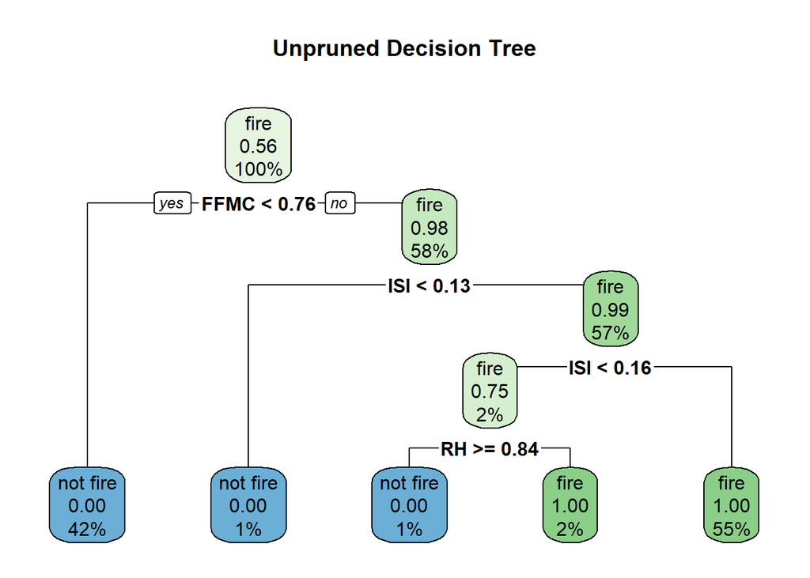

```r
# Train an unpruned decision tree
unpruned_tree <- rpart(Classes ~ Temperature + RH + Rain + FFMC + DMC + DC + ISI + BUI + FWI, data = train_normalized, method = "class", control = rpart.control(minsplit = 2, # An internal node will split if there are at least 2 observations.
                                            minbucket = 1, # A leaf node will contain at least 1 observation.
                                            cp = 0)) # The tree will grow as large as possible.

# Plot the trees
rpart.plot(unpruned_tree, main = "Unpruned Decision Tree")
```

```r
# Evaluate on test set
models$unpruned_preds <- predict(unpruned_tree, test_normalized, type = "class")

summary(unpruned_tree)
```

```
## Call:
## rpart(formula = Classes ~ Temperature + RH + Rain + FFMC + DMC +
##     DC + ISI + BUI + FWI, data = train_normalized, method = "class",
##     control = rpart.control(minsplit = 2, minbucket = 1, cp = 0))
##   n= 170
##
##            CP nsplit  rel error     xerror       xstd
## 1 0.972972973      0 1.00000000 1.00000000 0.08735651
## 2 0.013513514      1 0.02702703 0.06756757 0.02976945
## 3 0.006756757      2 0.01351351 0.08108108 0.03251183
## 4 0.000000000      4 0.00000000 0.06756757 0.02976945
##
## Variable importance
## FFMC  ISI  FWI  DMC  BUI   DC
##   20   20   18   14   14   13
##
## Node number 1: 170 observations,    complexity param=0.972973
##   predicted class=fire      expected loss=0.4352941  P(node) =1
##     class counts:    74    96
##    probabilities: 0.435 0.565
##   left son=2 (72 obs) right son=3 (98 obs)
##   Primary splits:
##       FFMC < 0.7648368  to the left,  improve=79.65810, (0 missing)
##       ISI  < 0.1605263  to the left,  improve=77.81024, (0 missing)
##       FWI  < 0.1125402  to the left,  improve=68.58650, (0 missing)
##       DMC  < 0.1142638  to the left,  improve=45.53166, (0 missing)
##       BUI  < 0.1023916  to the left,  improve=43.63474, (0 missing)
##   Surrogate splits:
##       ISI < 0.1289474  to the left,  agree=0.988, adj=0.972, (0 split)
##       FWI < 0.09324759 to the left,  agree=0.947, adj=0.875, (0 split)
##       DMC < 0.1142638  to the left,  agree=0.871, adj=0.694, (0 split)
##       BUI < 0.1023916  to the left,  agree=0.859, adj=0.667, (0 split)
##       DC  < 0.05454545 to the left,  agree=0.847, adj=0.639, (0 split)
##
## Node number 2: 72 observations
##   predicted class=not fire  expected loss=0  P(node) =0.4235294
##     class counts:    72     0
##    probabilities: 1.000 0.000
##
## Node number 3: 98 observations,    complexity param=0.01351351
```

[output cut: 42 more lines]

```
##
## Node number 15: 93 observations
##   predicted class=fire      expected loss=0  P(node) =0.5470588
##     class counts:     0    93
##    probabilities: 0.000 1.000
##
## Node number 28: 1 observations
##   predicted class=not fire  expected loss=0  P(node) =0.005882353
##     class counts:     1     0
##    probabilities: 1.000 0.000
##
## Node number 29: 3 observations
##   predicted class=fire      expected loss=0  P(node) =0.01764706
##     class counts:     0     3
##    probabilities: 0.000 1.000
```

```r
# Creating a confusion matrix to evaluate the model
conf_matrix_unpruned <- confusionMatrix(data = models$unpruned_preds, reference = test_normalized$Classes)
print(conf_matrix_unpruned)
```

```
## Confusion Matrix and Statistics
##
##           Reference
## Prediction not fire fire
##   not fire       31    1
##   fire            1   40
##
##                Accuracy : 0.9726
##                  95% CI : (0.9045, 0.9967)
##     No Information Rate : 0.5616
##     P-Value [Acc > NIR] : 8.52e-16
##
##                   Kappa : 0.9444
##
##  Mcnemar's Test P-Value : 1
##
##             Sensitivity : 0.9688
##             Specificity : 0.9756
##          Pos Pred Value : 0.9688
##          Neg Pred Value : 0.9756
##              Prevalence : 0.4384
##          Detection Rate : 0.4247
##    Detection Prevalence : 0.4384
##       Balanced Accuracy : 0.9722
##
##        'Positive' Class : not fire
##
```

The confusion matrix and associated statistics for the unpruned decision tree model indicate strong performance. The model achieved an overall accuracy of 97.26%, with a 95% confidence interval ranging from 90.45% to 99.67%. It exhibits high sensitivity (96.88%) and specificity (97.56%), indicating that it is both good at correctly identifying instances of fire (true positives) and not fire (true negatives).

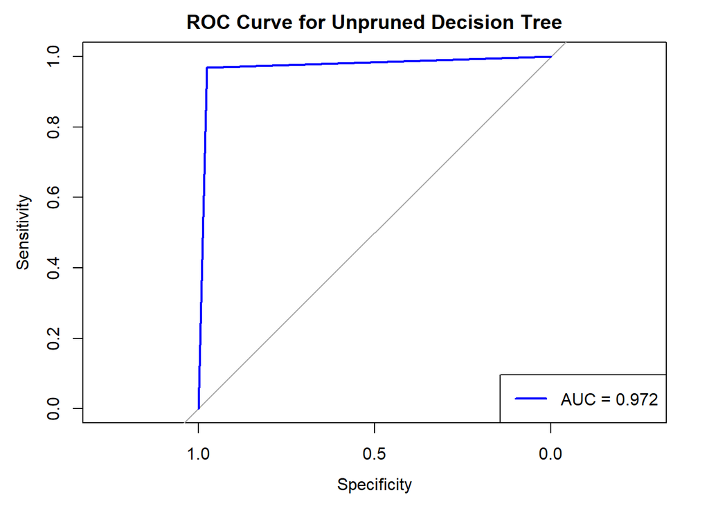

```r
# Predict probabilities on the test set
models$unpruned_probabilities <- predict(unpruned_tree, test_normalized, type = "prob")

# Extract probabilities for the positive class
positive_class_probs <- models$unpruned_probabilities[, 2]

# Generate the ROC curve
roc_curve_unpruned <- roc(test_normalized$Classes, positive_class_probs, levels = rev(levels(test_normalized$Classes))) # Ensure levels are ordered correctly

# Plot the ROC curve
plot(roc_curve_unpruned, main = "ROC Curve for Unpruned Decision Tree", col = "blue", lwd = 2)

# Calculate the AUC
auc_unpruned <- auc(roc_curve_unpruned)

# Add the AUC to the plot
legend("bottomright", legend = paste("AUC =", round(auc_unpruned, 3)), col = "blue", lwd = 2)
```

With an AUC of 0.972, the model demonstrates excellent discriminative ability, suggesting that it performs almost perfectly at distinguishing between fire and not fire instances. This high AUC value further reinforces the results from the confusion matrix, showing that the unpruned decision tree is highly effective at classifying the data.

```r
unpruned_metrics <- conf_matrix_unpruned$byClass

# Append unpruned results to the performance metrics table
performance_metrics["Unpruned Trees", ] <- c(
  Sensitivity = unpruned_metrics['Sensitivity'],
  Specificity = unpruned_metrics['Specificity'],
  Positive_Predictive_Value = unpruned_metrics['Pos Pred Value'],
  Negative_Predictive_Value = unpruned_metrics['Neg Pred Value'],
  Prevalence = mean(test_normalized$Classes == "fire"),
  Detection_Rate = unpruned_metrics['Detection Rate'],
  Detection_Prevalence = unpruned_metrics['Detection Prevalence'],
  Balanced_Accuracy = unpruned_metrics['Balanced Accuracy'],
  AUC = auc_unpruned
)
```

#### Pruned Trees

This code examines the complexity parameters of an unpruned decision tree to identify the optimal value for pruning, the one that minimizes the cross-validation error.

```r
# Examine the complexity parameters
printcp(unpruned_tree)  # Prints a table of complexity parameters and cross-validation errors
```

```
##
## Classification tree:
## rpart(formula = Classes ~ Temperature + RH + Rain + FFMC + DMC +
##     DC + ISI + BUI + FWI, data = train_normalized, method = "class",
##     control = rpart.control(minsplit = 2, minbucket = 1, cp = 0))
##
## Variables actually used in tree construction:
## [1] FFMC ISI  RH
##
## Root node error: 74/170 = 0.43529
##
## n= 170
##
##          CP nsplit rel error   xerror     xstd
## 1 0.9729730      0  1.000000 1.000000 0.087357
## 2 0.0135135      1  0.027027 0.067568 0.029769
## 3 0.0067568      2  0.013514 0.081081 0.032512
## 4 0.0000000      4  0.000000 0.067568 0.029769
```

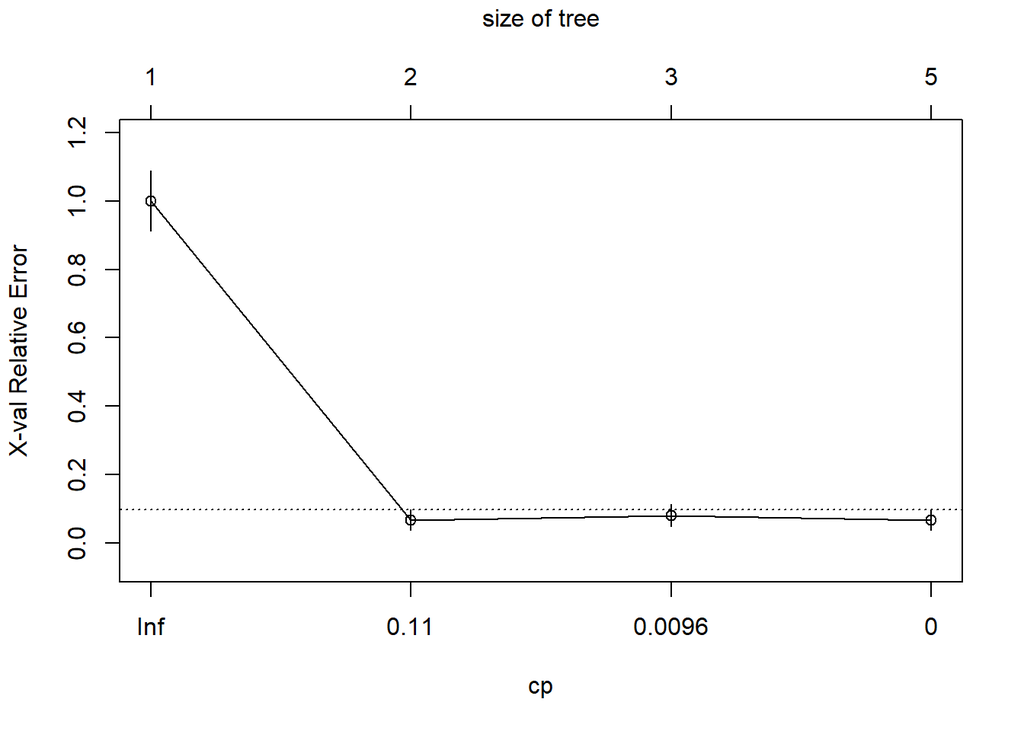

```r
plotcp(unpruned_tree)   # Plots the cross-validation error against cp values
```

```r
# Identify the best cp value (the one with the smallest xerror)
optimal_cp <- unpruned_tree$cptable[which.min(unpruned_tree$cptable[, "xerror"]), "CP"]
cat("Optimal cp value:", optimal_cp, "\n")
```

```
## Optimal cp value: 0.01351351
```

The optimal cp value, identified as 0.01351351, is the one that minimizes the cross-validation error (xerror). This value strikes a balance between tree complexity and overfitting, ensuring that the model is simplified without losing accuracy. This value is used to prune the tree.

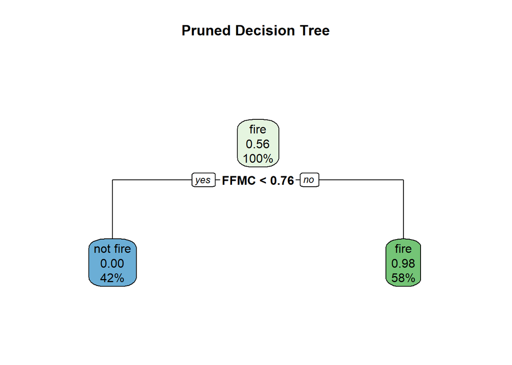

```r
# Prune the tree using the optimal cp value
pruned_tree <- prune(unpruned_tree, cp = optimal_cp)

# Visualize the pruned tree
rpart.plot(pruned_tree, main = "Pruned Decision Tree")
```

```r
summary(pruned_tree)
```

```
## Call:
## rpart(formula = Classes ~ Temperature + RH + Rain + FFMC + DMC +
##     DC + ISI + BUI + FWI, data = train_normalized, method = "class",
##     control = rpart.control(minsplit = 2, minbucket = 1, cp = 0))
##   n= 170
##
##           CP nsplit  rel error     xerror       xstd
## 1 0.97297297      0 1.00000000 1.00000000 0.08735651
## 2 0.01351351      1 0.02702703 0.06756757 0.02976945
##
## Variable importance
## FFMC  ISI  FWI  DMC  BUI   DC
##   21   20   18   14   14   13
##
## Node number 1: 170 observations,    complexity param=0.972973
##   predicted class=fire      expected loss=0.4352941  P(node) =1
##     class counts:    74    96
##    probabilities: 0.435 0.565
##   left son=2 (72 obs) right son=3 (98 obs)
##   Primary splits:
##       FFMC < 0.7648368  to the left,  improve=79.65810, (0 missing)
##       ISI  < 0.1605263  to the left,  improve=77.81024, (0 missing)
##       FWI  < 0.1125402  to the left,  improve=68.58650, (0 missing)
##       DMC  < 0.1142638  to the left,  improve=45.53166, (0 missing)
##       BUI  < 0.1023916  to the left,  improve=43.63474, (0 missing)
##   Surrogate splits:
##       ISI < 0.1289474  to the left,  agree=0.988, adj=0.972, (0 split)
##       FWI < 0.09324759 to the left,  agree=0.947, adj=0.875, (0 split)
##       DMC < 0.1142638  to the left,  agree=0.871, adj=0.694, (0 split)
##       BUI < 0.1023916  to the left,  agree=0.859, adj=0.667, (0 split)
##       DC  < 0.05454545 to the left,  agree=0.847, adj=0.639, (0 split)
##
## Node number 2: 72 observations
##   predicted class=not fire  expected loss=0  P(node) =0.4235294
##     class counts:    72     0
##    probabilities: 1.000 0.000
##
## Node number 3: 98 observations
##   predicted class=fire      expected loss=0.02040816  P(node) =0.5764706
##     class counts:     2    96
##    probabilities: 0.020 0.980
```

```r
#Predict on test data and calculate accuracy
models$pruned_preds <- predict(pruned_tree, newdata = test_normalized, type = "class")

# Creating a confusion matrix to evaluate the model
conf_matrix_pruned <- confusionMatrix(data = models$pruned_preds, reference = test_normalized$Classes)

print(conf_matrix_pruned)
```

```
## Confusion Matrix and Statistics
##
##           Reference
## Prediction not fire fire
##   not fire       30    0
##   fire            2   41
##
##                Accuracy : 0.9726
##                  95% CI : (0.9045, 0.9967)
##     No Information Rate : 0.5616
##     P-Value [Acc > NIR] : 8.52e-16
##
##                   Kappa : 0.944
##
##  Mcnemar's Test P-Value : 0.4795
##
##             Sensitivity : 0.9375
##             Specificity : 1.0000
##          Pos Pred Value : 1.0000
##          Neg Pred Value : 0.9535
##              Prevalence : 0.4384
##          Detection Rate : 0.4110
##    Detection Prevalence : 0.4110
##       Balanced Accuracy : 0.9688
##
##        'Positive' Class : not fire
##
```

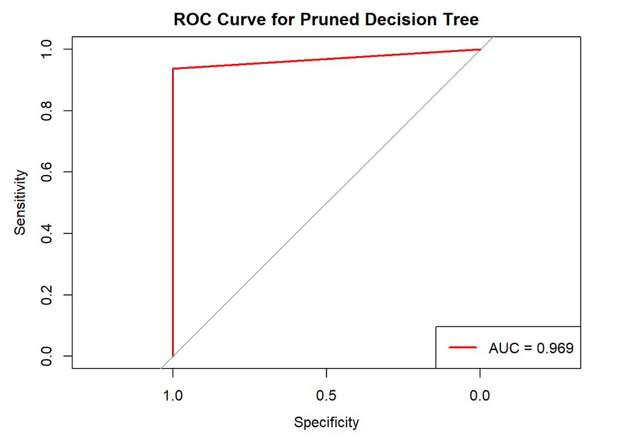

```r
# Predict probabilities on the test set for the pruned tree
models$pruned_probabilities <- predict(pruned_tree, test_normalized, type = "prob")

# Extract probabilities for the positive class
positive_class_probs_pruned <- models$pruned_probabilities[, 2]

# Generate the ROC curve for the pruned tree
roc_curve_pruned <- roc(test_normalized$Classes, positive_class_probs_pruned, levels = rev(levels(test_normalized$Classes)))  # Ensure correct level ordering

# Plot the ROC curve for the pruned tree
plot(roc_curve_pruned, main = "ROC Curve for Pruned Decision Tree", col = "red", lwd = 2)

# Calculate the AUC for the pruned tree
auc_pruned <- auc(roc_curve_pruned)

# Add AUC value to the plot
legend("bottomright", legend = paste("AUC =", round(auc_pruned, 3)), col = "red", lwd = 2)
```

An AUC of 0.969 indicates that the model has excellent performance in distinguishing between the 2 classes—“fire” and “not fire”. This high AUC aligns with the other performance metrics, like accuracy and sensitivity, which demonstrate that the model is not only accurate but also very reliable in differentiating between the two classes.

```r
pruned_metrics <- conf_matrix_pruned$byClass

# Append pruned results to the performance metrics table
performance_metrics["Pruned Trees", ] <- c(
  Sensitivity = pruned_metrics['Sensitivity'],
  Specificity = pruned_metrics['Specificity'],
  Positive_Predictive_Value = pruned_metrics['Pos Pred Value'],
  Negative_Predictive_Value = pruned_metrics['Neg Pred Value'],
  Prevalence = mean(test_normalized$Classes == "fire"),
  Detection_Rate = pruned_metrics['Detection Rate'],
  Detection_Prevalence = pruned_metrics['Detection Prevalence'],
  Balanced_Accuracy = pruned_metrics['Balanced Accuracy'],
  AUC = auc_pruned
)
```

### Bagging

This code applies the bagging technique for classification. Bagging or Bootstrap Aggregating is an ensemble learning method that improves the stability and accuracy of machine learning algorithms.

```r
# Ensure Classes is a factor for classification
train_normalized$Classes <- as.factor(train_normalized$Classes)
test_normalized$Classes <- as.factor(test_normalized$Classes)

# Bagging with all features
set.seed(1)
bag_model <- randomForest(Classes ~ Temperature + RH + Rain + FFMC + DMC + DC + ISI + BUI + FWI, data = train_normalized, mtry = 9, importance = TRUE)

# Print the bagging model details
print(bag_model)
```

```
##
## Call:
##  randomForest(formula = Classes ~ Temperature + RH + Rain + FFMC +      DMC + DC + ISI + BUI + FWI, data = train_normalized, mtry = 9,      importance = TRUE)
##                Type of random forest: classification
##                      Number of trees: 500
## No. of variables tried at each split: 9
##
##         OOB estimate of  error rate: 2.35%
## Confusion matrix:
##          not fire fire class.error
## not fire       72    2  0.02702703
## fire            2   94  0.02083333
```

```r
# Predict on test data
models$bag_preds <- predict(bag_model, newdata = test_normalized)
```

The bagging model, implemented using a random forest algorithm with 500 trees, demonstrates excellent performance in classifying the “fire” and “not fire” classes. The Out-of-Bag (OOB) error rate is remarkably low at 2.35%, indicating that the model generalizes well and is not overfitting. The confusion matrix further confirms the model’s high accuracy, with only 2 false negatives (not predicting fire when it is actually fire) and 2 false positives (predicting fire when it is actually not fire). This results in very low class errors: 2.7% for “not fire” and 2.1% for “fire.” These results suggest that the model is highly effective in distinguishing between the two classes, with a minimal error rate overall. The use of 9 variables at each split appears to have contributed to the model’s strong predictive performance.

```r
# Confusion Matrix
conf_matrix_bag <- confusionMatrix(data = models$bag_preds, reference = test_normalized$Classes)
print(conf_matrix_bag)
```

```
## Confusion Matrix and Statistics
##
##           Reference
## Prediction not fire fire
##   not fire       31    0
##   fire            1   41
##
##                Accuracy : 0.9863
##                  95% CI : (0.926, 0.9997)
##     No Information Rate : 0.5616
##     P-Value [Acc > NIR] : <2e-16
##
##                   Kappa : 0.9721
##
##  Mcnemar's Test P-Value : 1
##
##             Sensitivity : 0.9688
##             Specificity : 1.0000
##          Pos Pred Value : 1.0000
##          Neg Pred Value : 0.9762
##              Prevalence : 0.4384
##          Detection Rate : 0.4247
##    Detection Prevalence : 0.4247
##       Balanced Accuracy : 0.9844
##
##        'Positive' Class : not fire
##
```

This confusion matrix shows that the model performs slightly better on the test data. The accuracy is very high at 98.63%, with a P-value less than 2e-16, indicating that the model significantly outperforms random guessing. The sensitivity (0.9688) indicates that the model successfully detects 96.88% of the “not fire” cases, while the specificity is perfect at 1, meaning the model correctly identifies all “fire” cases. Additionally, the positive predictive value is 1, which means that when the model predicts “not fire,” it is correct 100% of the time. The negative predictive value is 0.9762, indicating that the model correctly classifies 97.62% of the “fire” cases when it predicts them. In conclusion, this bagging model performs exceptionally well with very few misclassifications.

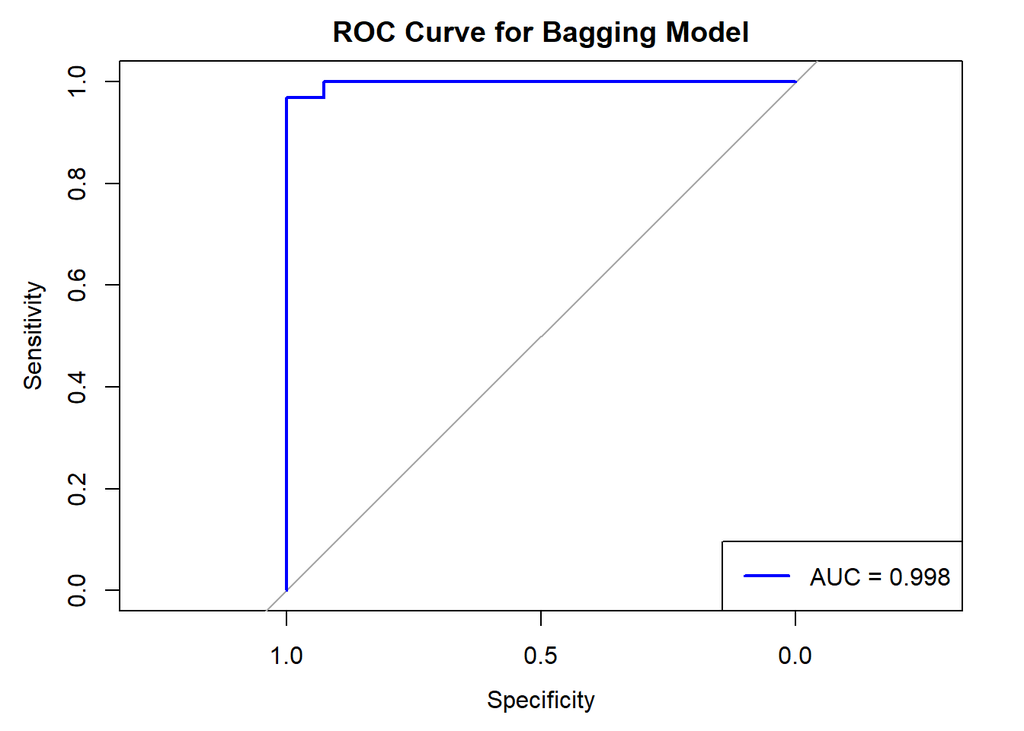

```r
# Predict probabilities for the ROC curve
models$bag_probabilities <- predict(bag_model, newdata = test_normalized, type = "prob")

# Extract probabilities for the positive class
positive_class_probs_bag <- models$bag_probabilities[, 2]

# Generate the ROC curve for the Bagging model
roc_curve_bag <- roc(test_normalized$Classes, positive_class_probs_bag,
                     levels = rev(levels(test_normalized$Classes)))  # Ensure correct level ordering

# Plot the ROC curve
plot(roc_curve_bag, main = "ROC Curve for Bagging Model", col = "blue", lwd = 2)

# Calculate the AUC for the Bagging model
auc_bag <- auc(roc_curve_bag)

# Add AUC value to the plot
legend("bottomright", legend = paste("AUC =", round(auc_bag, 3)), col = "blue", lwd = 2)
```

Given the AUC of 0.998, the model performs with a very high level of precision, and its ROC curve is very close to the top-left corner of the plot, indicating that the model successfully distinguishes between the two classes with minimal errors. The AUC value reinforces the strong performance of the model, confirming that it has an excellent ability to predict both “fire” and “not fire” correctly.

```r
bag_metrics <- conf_matrix_bag$byClass

# Append bagging results to the performance metrics table
performance_metrics["Bagging", ] <- c(
  Sensitivity = bag_metrics['Sensitivity'],
  Specificity = bag_metrics['Specificity'],
  Positive_Predictive_Value = bag_metrics['Pos Pred Value'],
  Negative_Predictive_Value = bag_metrics['Neg Pred Value'],
  Prevalence = mean(test_normalized$Classes == "fire"),
  Detection_Rate = bag_metrics['Detection Rate'],
  Detection_Prevalence = bag_metrics['Detection Prevalence'],
  Balanced_Accuracy = bag_metrics['Balanced Accuracy'],
  AUC = auc_bag
)
```

### Random Forest

Random Forest is an ensemble learning method that builds multiple decision trees during training and combines their predictions to improve accuracy and reduce overfitting.

```r
# Train Random Forest
set.seed(42)
rf_model <- randomForest(Classes ~ Temperature + RH + Rain + FFMC + DMC + DC + ISI + BUI + FWI, data = train_normalized, ntree = 100, importance = TRUE)

# Predict on test data
models$rf_pred <- predict(rf_model, test_normalized)

# Evaluate performance
conf_matrix_RF <- confusionMatrix(models$rf_pred, test_normalized$Classes)
print(conf_matrix_RF)
```

```
## Confusion Matrix and Statistics
##
##           Reference
## Prediction not fire fire
##   not fire       30    0
##   fire            2   41
##
##                Accuracy : 0.9726
##                  95% CI : (0.9045, 0.9967)
##     No Information Rate : 0.5616
##     P-Value [Acc > NIR] : 8.52e-16
##
##                   Kappa : 0.944
##
##  Mcnemar's Test P-Value : 0.4795
##
##             Sensitivity : 0.9375
##             Specificity : 1.0000
##          Pos Pred Value : 1.0000
##          Neg Pred Value : 0.9535
##              Prevalence : 0.4384
##          Detection Rate : 0.4110
##    Detection Prevalence : 0.4110
##       Balanced Accuracy : 0.9688
##
##        'Positive' Class : not fire
##
```

The results from the Random Forest model show excellent performance, with an overall accuracy of 97.26%. The sensitivity of 93.75% indicates that the model is highly effective at correctly identifying the “not fire” class, while the specificity of 100% shows it is flawless in identifying the “fire” class. The positive predictive value of 100% and negative predictive value of 95.35% highlight the model’s reliability in both classes. Overall, the model demonstrates robust performance across all metrics, with a balanced accuracy of 96.88%.

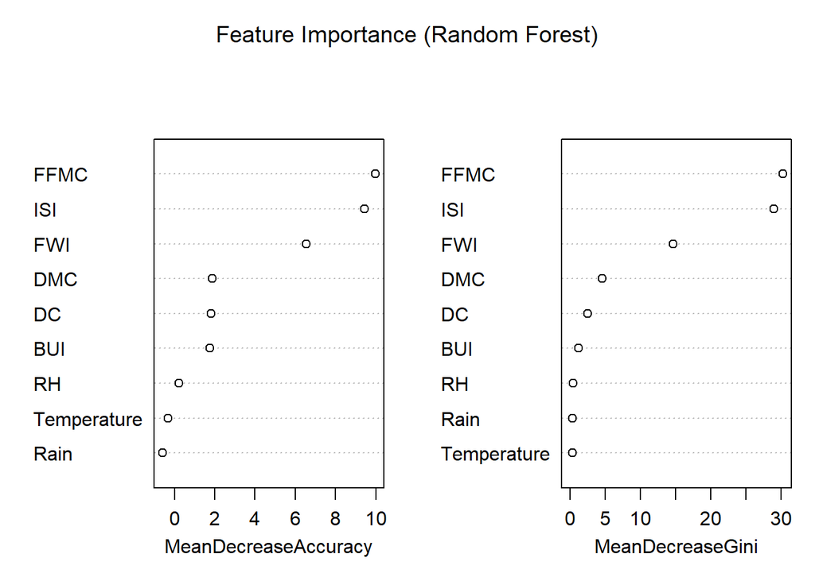

```r
# Feature Importance
importance <- importance(rf_model)
varImpPlot(rf_model, main = "Feature Importance (Random Forest)")
```

The feature importance plot from the Random Forest model indicates again that *FFMC*, *ISI*, and *FWI* are the most significant predictors, contributing the most to both model accuracy and node purity. In contrast, features like *Rain* and *Temperature* have minimal influence, highlighting the critical role of fire weather indices in predicting the target variable.

```r
# Predict on test data (probabilities for ROC curve)
models$rf_prob <- predict(rf_model, test_normalized, type = "prob")

# Extract probabilities for the positive class
positive_class_probs_rf <- models$rf_prob[, 2]

# Generate the ROC curve
roc_curve_rf <- roc(test_normalized$Classes, positive_class_probs_rf,
                    levels = rev(levels(test_normalized$Classes)))  # Ensure correct level ordering

# Plot the ROC curve
plot(roc_curve_rf, main = "ROC Curve for Random Forest Model", col = "darkgreen", lwd = 2)

# Calculate the AUC
auc_RF <- auc(roc_curve_rf)
cat("AUC for Random Forest Model:", auc_RF, "\n")
```

```
## AUC for Random Forest Model: 0.9984756
```

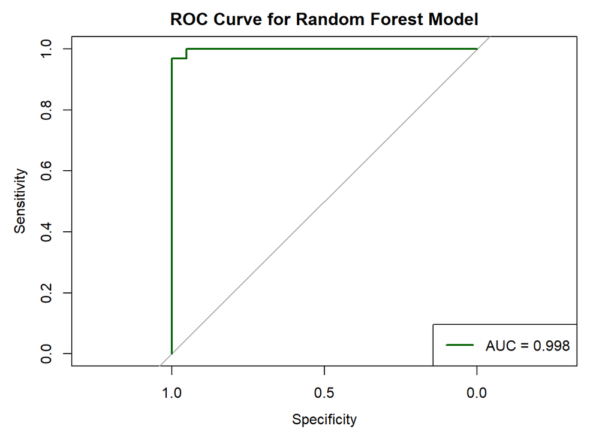

```r
# Add AUC value to the plot
legend("bottomright", legend = paste("AUC =", round(auc_RF, 3)), col = "darkgreen", lwd = 2)
```

An AUC of 0.998 indicates that the model is almost perfect at identifying the correct class, with very few misclassifications, and this strong performance is confirmed by the fact that it has a near-ideal ROC curve shape.

```r
RF_metrics <- conf_matrix_RF$byClass

# Append random forest results to the performance metrics table
performance_metrics["Random Forest", ] <- c(
  Sensitivity = RF_metrics['Sensitivity'],
  Specificity = RF_metrics['Specificity'],
  Positive_Predictive_Value = RF_metrics['Pos Pred Value'],
  Negative_Predictive_Value = RF_metrics['Neg Pred Value'],
  Prevalence = mean(test_normalized$Classes == "fire"),
  Detection_Rate = RF_metrics['Detection Rate'],
  Detection_Prevalence = RF_metrics['Detection Prevalence'],
  Balanced_Accuracy = RF_metrics['Balanced Accuracy'],
  AUC = auc_RF
)
```